# DDSAnalytics - Attrition Analysis

Katon Pang

2023-12-23

# Introduction

DDSAnalytics is a talent management company serving Fortune 100 companies. Our team was provided with a dataset comprising existing employees of Frito Lay, with the aim of identifying factors contributing to attrition. The dataset includes information on employees, such as attrition status, monthly salary, satisfaction ratings, job roles, departments, etc. The objective of this study is threefold: first, to identify the top three factors contributing to attrition; second, to develop models predicting both attrition and monthly income; and third, to uncover job role-specific trends and other insightful information.

#### Presentation

The presentation of this study:  
https://youtu.be/MTaajBOWc4o

#### Shiny App

The link below allows you to explore ratings from employee dataset.  
https://katonp.shinyapps.io/Attrition/

## Obtain employee and test datasets from AWS S3

```r
# Getting the employee dataset from S3 URL
case <- read.table(textConnection(getURL(
  "https://s3.us-east-2.amazonaws.com/msdsds6306/CaseStudy2-data.csv"
)), sep=",", header=TRUE)
## There are 870 observation with 36 variables.

# Getting the new dataset from S3 URL for attrition prediction
test_attr <- read.table(textConnection(getURL(
  "https://s3.us-east-2.amazonaws.com/msdsds6306/CaseStudy2CompSet%20No%20Attrition.csv"
)), sep=",", header=TRUE)

# Getting the new dataset from S3 URL for monthly income prediction
test_salary <- read.table(textConnection(getURL(
  "https://s3.us-east-2.amazonaws.com/msdsds6306/CaseStudy2CompSet%20No%20Salary.csv"
)), sep=",", header=TRUE)
```

```r
# Summary of data
summary(case)
```

```
##        ID             Age         Attrition         BusinessTravel
##  Min.   :  1.0   Min.   :18.00   Length:870         Length:870
##  1st Qu.:218.2   1st Qu.:30.00   Class :character   Class :character
##  Median :435.5   Median :35.00   Mode  :character   Mode  :character
##  Mean   :435.5   Mean   :36.83
##  3rd Qu.:652.8   3rd Qu.:43.00
##  Max.   :870.0   Max.   :60.00
##    DailyRate       Department        DistanceFromHome   Education
##  Min.   : 103.0   Length:870         Min.   : 1.000   Min.   :1.000
##  1st Qu.: 472.5   Class :character   1st Qu.: 2.000   1st Qu.:2.000
##  Median : 817.5   Mode  :character   Median : 7.000   Median :3.000
##  Mean   : 815.2                      Mean   : 9.339   Mean   :2.901
##  3rd Qu.:1165.8                      3rd Qu.:14.000   3rd Qu.:4.000
##  Max.   :1499.0                      Max.   :29.000   Max.   :5.000
##  EducationField     EmployeeCount EmployeeNumber   EnvironmentSatisfaction
##  Length:870         Min.   :1     Min.   :   1.0   Min.   :1.000
##  Class :character   1st Qu.:1     1st Qu.: 477.2   1st Qu.:2.000
##  Mode  :character   Median :1     Median :1039.0   Median :3.000
##                     Mean   :1     Mean   :1029.8   Mean   :2.701
##                     3rd Qu.:1     3rd Qu.:1561.5   3rd Qu.:4.000
##                     Max.   :1     Max.   :2064.0   Max.   :4.000
##     Gender            HourlyRate     JobInvolvement     JobLevel
##  Length:870         Min.   : 30.00   Min.   :1.000   Min.   :1.000
##  Class :character   1st Qu.: 48.00   1st Qu.:2.000   1st Qu.:1.000
##  Mode  :character   Median : 66.00   Median :3.000   Median :2.000
##                     Mean   : 65.61   Mean   :2.723   Mean   :2.039
##                     3rd Qu.: 83.00   3rd Qu.:3.000   3rd Qu.:3.000
##                     Max.   :100.00   Max.   :4.000   Max.   :5.000
##    JobRole          JobSatisfaction MaritalStatus      MonthlyIncome
##  Length:870         Min.   :1.000   Length:870         Min.   : 1081
##  Class :character   1st Qu.:2.000   Class :character   1st Qu.: 2840
##  Mode  :character   Median :3.000   Mode  :character   Median : 4946
##                     Mean   :2.709                      Mean   : 6390
##                     3rd Qu.:4.000                      3rd Qu.: 8182
##                     Max.   :4.000                      Max.   :19999
##   MonthlyRate    NumCompaniesWorked    Over18            OverTime
##  Min.   : 2094   Min.   :0.000      Length:870         Length:870
##  1st Qu.: 8092   1st Qu.:1.000      Class :character   Class :character
##  Median :14074   Median :2.000      Mode  :character   Mode  :character
##  Mean   :14326   Mean   :2.728
```

[output cut: 15 more lines]

```
##  Max.   :3.0000   Max.   :40.00     Max.   :6.000         Max.   :4.000
##  YearsAtCompany   YearsInCurrentRole YearsSinceLastPromotion
##  Min.   : 0.000   Min.   : 0.000     Min.   : 0.000
##  1st Qu.: 3.000   1st Qu.: 2.000     1st Qu.: 0.000
##  Median : 5.000   Median : 3.000     Median : 1.000
##  Mean   : 6.962   Mean   : 4.205     Mean   : 2.169
##  3rd Qu.:10.000   3rd Qu.: 7.000     3rd Qu.: 3.000
##  Max.   :40.000   Max.   :18.000     Max.   :15.000
##  YearsWithCurrManager
##  Min.   : 0.00
##  1st Qu.: 2.00
##  Median : 3.00
##  Mean   : 4.14
##  3rd Qu.: 7.00
##  Max.   :17.00
```

Within the 36 variables, the data consists of both qualitative and quantitative variables. Some variables, like YearAtCompany and TotalWorkingYears, exhibit a highly right-skewed distribution.

```r
# Checking any missing data
sum(is.na(case))
```

```
## [1] 0
```

There is no missing data in the employee dataset.

# Attrition

## Exploratory Data Analysis (EDA)

### Pairwise correlation

Begin by examining correlation coefficients between Attrition and other variables to gain a general understanding. Subsequently, employ visualization techniques and additional statistical analyses to further explore these relationships.

```r
# Duplicate the original dataset
case2 = case

# Change nonnumeric variables into numeric
case2$Attrition[case2$Attrition == "Yes"] = 0
case2$Attrition[case2$Attrition == "No"] = 1
case2$Attrition = as.numeric(case2$Attrition)

case2$BusinessTravel[case2$BusinessTravel == "Non-Travel"] = 0
case2$BusinessTravel[case2$BusinessTravel == "Travel_Rarely"] = 1
case2$BusinessTravel[case2$BusinessTravel == "Travel_Frequently"] = 2
case2$BusinessTravel = as.numeric(case2$BusinessTravel)

case2$Department[case2$Department == "Human Resources"] = 0
case2$Department[case2$Department == "Research & Development"] = 1
case2$Department[case2$Department == "Sales"] = 2
case2$Department = as.numeric(case2$Department)

case2$EducationField[case2$EducationField == "Human Resources"] = 0
case2$EducationField[case2$EducationField == "Life Sciences"] = 1
case2$EducationField[case2$EducationField == "Medical"] = 2
case2$EducationField[case2$EducationField == "Marketing"] = 3
case2$EducationField[case2$EducationField == "Technical Degree"] = 4
case2$EducationField[case2$EducationField == "Other"] = 5
case2$EducationField = as.numeric(case2$EducationField)

case2$Gender[case2$Gender == "Female"] = 0
case2$Gender[case2$Gender == "Male"] = 1
case2$Gender = as.numeric(case2$Gender)

case2$JobRole[case2$JobRole == "Healthcare Representative"] = 0
case2$JobRole[case2$JobRole == "Human Resources"] = 1
case2$JobRole[case2$JobRole == "Laboratory Technician"] = 2
case2$JobRole[case2$JobRole == "Manager"] = 3
case2$JobRole[case2$JobRole == "Manufacturing Director"] = 4
case2$JobRole[case2$JobRole == "Research Director"] = 5
case2$JobRole[case2$JobRole == "Research Scientist"] = 6
case2$JobRole[case2$JobRole == "Sales Executive"] = 7
case2$JobRole[case2$JobRole == "Sales Representative"] = 8
case2$JobRole = as.numeric(case2$JobRole)

case2$MaritalStatus[case2$MaritalStatus == "Divorced"] = 0
case2$MaritalStatus[case2$MaritalStatus == "Single"] = 1
case2$MaritalStatus[case2$MaritalStatus == "Married"] = 2
case2$MaritalStatus = as.numeric(case2$MaritalStatus)

case2$OverTime[case2$OverTime == "Yes"] = 0
case2$OverTime[case2$OverTime == "No"] = 1
case2$OverTime = as.numeric(case2$OverTime)
```

```r
summary(case2)
str(case2)
```

There are several variables that either lack distinct characteristics among different employees or serve as identification numbers. These variables will be removed from the data frame ‘case2’ before conducting further analysis. The identified variables are as follows:

ID: Identification variable  
EmployeeCount: All 1’s  
EmployeeNumber: Identification Variable  
StandardHours: All 80’s  
Over18: All Yes’s

```r
# Remove column ID, EmployeeCount, EmployeeNumber, Over18, and StandardHours
case2$ID <- c()
case2$EmployeeCount <- c()
case2$EmployeeNumber <- c()
case2$Over18 <- c()
case2$StandardHours <-c()
```

```r
# Pairwise correlations
cor_matrix <- cor_mat(case2)
# Display with p-values
cor_p = cor_matrix %>% cor_gather()
# See Attrition only
Acor_p = cor_p %>% filter(var2 == "Attrition")
# Arrange by the absolute value of correlation coefficients in descending order
Acor_p = arrange(Acor_p, desc(abs(cor)))
# The top 10 variables of the list
Acor_p[2:11,]
```

```
## # A tibble: 10 × 4
##    var1                 var2        cor        p
##    <chr>                <chr>     <dbl>    <dbl>
##  1 OverTime             Attrition  0.27 3.16e-16
##  2 JobInvolvement       Attrition  0.19 2.39e- 8
##  3 TotalWorkingYears    Attrition  0.17 7.06e- 7
##  4 JobLevel             Attrition  0.16 1.53e- 6
##  5 YearsInCurrentRole   Attrition  0.16 3.67e- 6
##  6 Age                  Attrition  0.15 9.66e- 6
##  7 MonthlyIncome        Attrition  0.15 4.42e- 6
##  8 StockOptionLevel     Attrition  0.15 1.06e- 5
##  9 YearsWithCurrManager Attrition  0.15 1.38e- 5
## 10 YearsAtCompany       Attrition  0.13 1.4 e- 4
```

### Graphs and statistical analysis

We will further investigate the top 10 variables, which exhibit the highest correlation coefficients, along with other interesting variables listed below.

Several common top reasons of employees attrition, along with the related variables from the dataset:  
1. Lack of purpose / boredom: JobInvolvement, JobSatisfaction  
2. Poor Compensation: Monthly Income  
3. Overworked: OverTime  
4. Poor work/life balance: WorkLifeBalance, DistanceFromHome, BusinessTravel  
5. Bad Managers: RelationshipSatisfication, YearsWithCurrManager

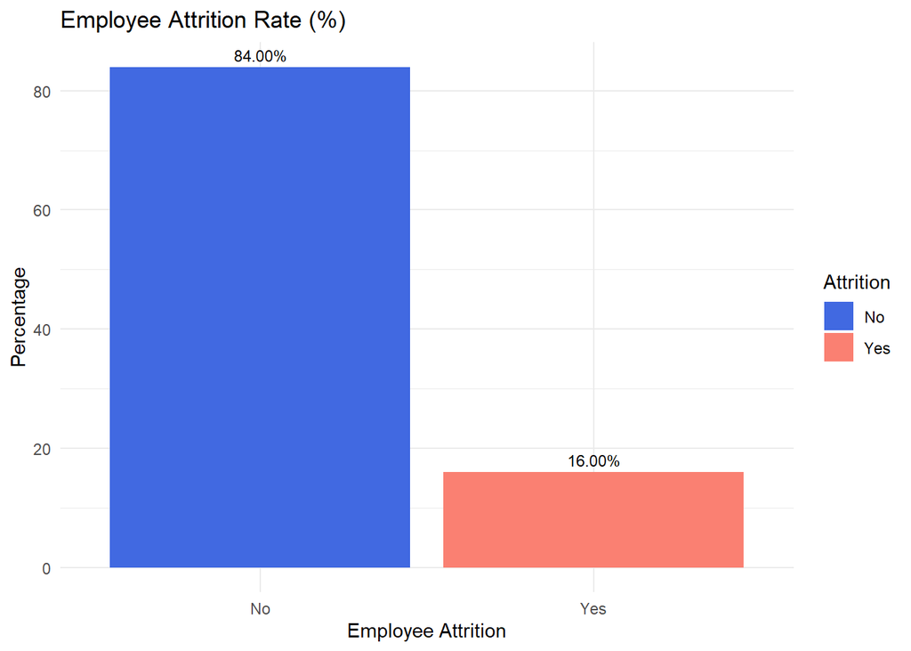

```r
# Employees Attrition Rate
case %>% group_by(Attrition) %>% summarise(Count=n()) %>% mutate(attr_pct=round(prop.table(Count),2) * 100) %>%
ggplot(aes(x=Attrition, y=attr_pct, fill = Attrition)) + geom_bar(stat="identity") + geom_text(aes(label= sprintf("%.2f%%", attr_pct)), vjust=-0.5, size=3) + labs(x="Employee Attrition", y="Percentage", title="Employee Attrition Rate (%)") + theme_minimal() + scale_fill_manual(values = c("royalblue", "salmon"))
```

This dataset is imbalanced, with only 16% (140 out of 870) of employees marked as ‘Yes’ in the Attrition category. We will address this imbalance by employing oversampling during the training and validation stages of the attrition models.

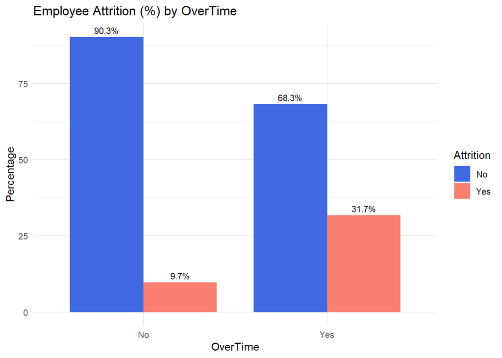

```r
# Attrition by OverTime
# Total number of employees based on OverTime
Attr_OT = case %>% select(OverTime, Attrition) %>% group_by(OverTime) %>% summarise(count=n())

# Find out the number of each Attrition status based on OverTime
# Combine the result with Attr_OT data frame
Attr_OT <- cbind(Attr_OT,as.data.frame.matrix(table(case$OverTime, case$Attrition)))

# Make Attr_OT into long dataset
Attr_OT_long <- gather(Attr_OT, Attrition, Qty, c(Yes,No))
# Add column and calculate the percentage of attrition
Attr_OT_long$pct = Attr_OT_long$Qty / Attr_OT_long$count *100

# Create the barplot
Attr_OT_long %>% ggplot(aes(x=OverTime, y=pct, fill=Attrition, label=pct)) + geom_col(width=0.8, position='dodge') + geom_text(aes(label= sprintf("%.1f%%", pct)), position=position_dodge(0.8), vjust=-0.5, size=3) + labs(x="OverTime", y="Percentage", title="Employee Attrition (%) by OverTime") + theme_minimal() + scale_fill_manual(values = c("royalblue", "salmon"))
```

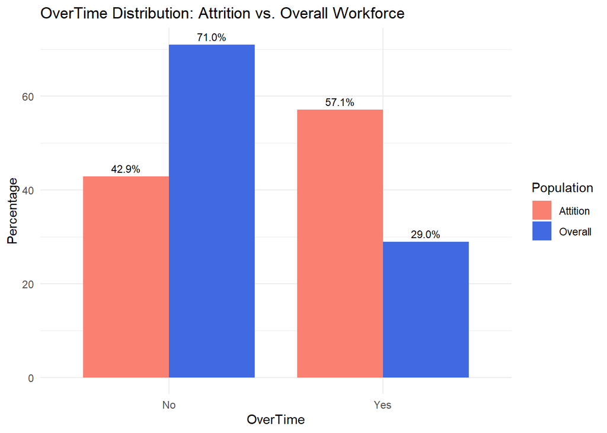

```r
# Comparing Overtime distributions between the overall workforce and the attrition group.
Comp = Attr_OT
Comp$Overall = Comp$count/870*100
Comp$Attition = Comp$Yes/140*100
Comp_long <- gather(Comp, Population, Pct, c(Overall,Attition))

# Create the barplot
Comp_long %>% ggplot(aes(x=OverTime, y=Pct, fill=Population, label=Pct)) + geom_col(width=0.8, position='dodge') + geom_text(aes(label= sprintf("%.1f%%", Pct)), position=position_dodge(0.8), vjust=-0.5, size=3)  + labs(x="OverTime", y="Percentage", title="OverTime Distribution: Attrition vs. Overall Workforce") + theme_minimal() +  scale_fill_manual(values = c("salmon", "royalblue"))
```

31.7% of employees who worked overtime left the company, compared to 9.7% of those who did not. Additionally, 57% of the employees who left the company had worked overtime. This underscores overtime as one of the top contributing factors to employee attrition.

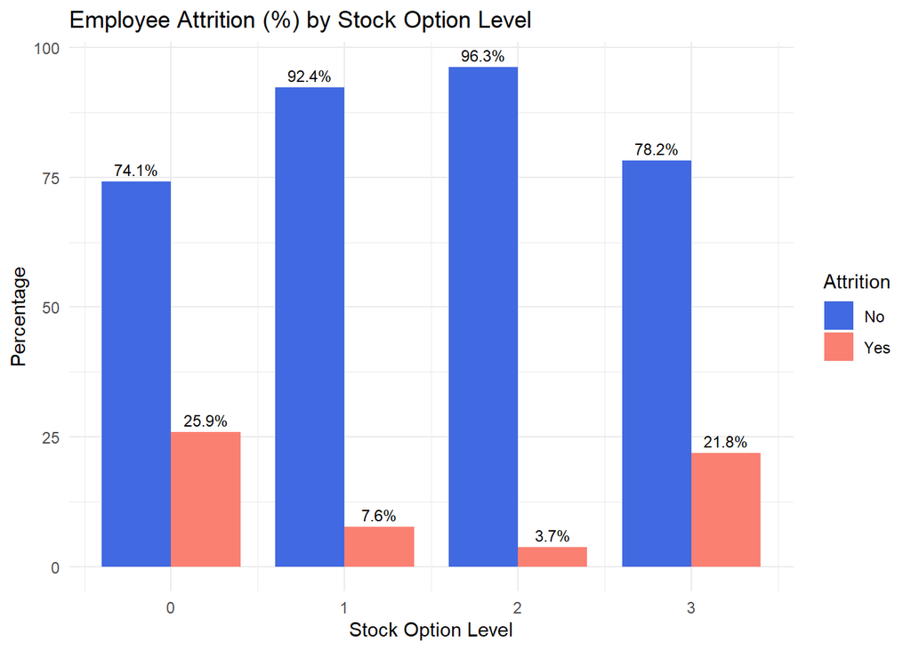

```r
# Attrition by Stock Option Level
# Total number of employees based on Stock Option Level
Attr_SO = case %>% select(StockOptionLevel, Attrition) %>% group_by(StockOptionLevel) %>% summarise(count=n())

# Find out the number of each Attrition status for each Stock Option Level
# Combine the result with Attr_SO data frame
Attr_SO <- cbind(Attr_SO,as.data.frame.matrix(table(case$StockOptionLevel, case$Attrition)))

# Make Attr_SO into long dataset
Attr_SO_long <- gather(Attr_SO, Attrition, Qty, c(Yes,No))
# Add column and calculate the percentage of attrition
Attr_SO_long$pct = Attr_SO_long$Qty / Attr_SO_long$count *100

# Create the barplot
Attr_SO_long %>% ggplot(aes(x=StockOptionLevel, y=pct, fill=Attrition, label=pct)) + geom_col(width=0.8, position='dodge') + geom_text(aes(label= sprintf("%.1f%%", pct)), position=position_dodge(0.8), vjust=-0.5, size=3) + labs(x="Stock Option Level", y="Percentage", title="Employee Attrition (%) by Stock Option Level") + theme_minimal() + scale_fill_manual(values = c("royalblue", "salmon"))
```

For the variable StockOptionLevel, where level 0 represents the lowest stock option possession and level 3 represents the highest, the bar plot shows significant differences in the percentages of employees who left the company across all stock option levels. Notably, levels 0 and 3 exhibit higher percentages (25.9% and 21.8%, respectively) compared to levels 1 and 2, which have lower percentages of 7.6% and 3.7%, respectively.

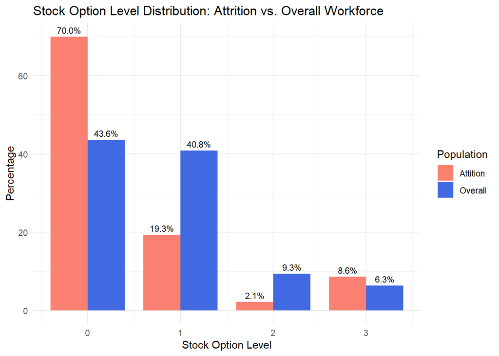

```r
# Comparing Stock Option Level distributions between the overall workforce and the attrition group.
Comp = Attr_SO
Comp$Overall = Comp$count/870*100
Comp$Attition = Comp$Yes/140*100
Comp_long <- gather(Comp, Population, Pct, c(Overall,Attition))

# Create the barplot
Comp_long %>% ggplot(aes(x=StockOptionLevel, y=Pct, fill=Population, label=Pct)) + geom_col(width=0.8, position='dodge') + geom_text(aes(label= sprintf("%.1f%%", Pct)), position=position_dodge(0.8), vjust=-0.5, size=3)  + labs(x="Stock Option Level", y="Percentage", title="Stock Option Level Distribution: Attrition vs. Overall Workforce") + theme_minimal() + scale_fill_manual(values = c("salmon", "royalblue"))
```

The percentage of employees who left the company at stock option level 0 is significantly higher than the corresponding percentage for this level across the entire company. This suggests that employees with the lowest stock option possession were more likely to leave the company in terms of composition.

Notably, 70% of employees who left the company were at the lowest stock option level. This underscores stock option level as one of the top indicative factors in employee attrition.

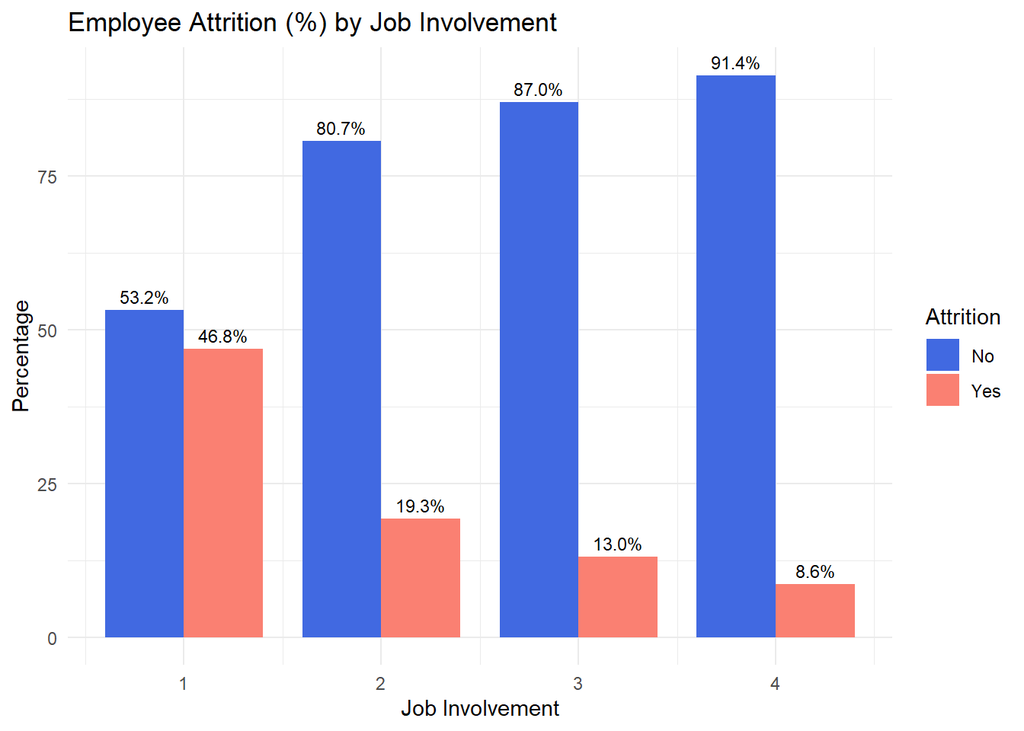

```r
# Attrition by Job Involvement
# Total number of employees in each Job Involvement rating
Attr_JI = case %>% select(JobInvolvement, Attrition) %>% group_by(JobInvolvement) %>% summarise(count=n())

# Find out the number of each Attrition status for each Job Involvement rating
# Combine the result with Attr_JI data frame
Attr_JI <- cbind(Attr_JI,as.data.frame.matrix(table(case$JobInvolvement, case$Attrition)))

# Make Attr_JI into long dataset
Attr_JI_long <- gather(Attr_JI, Attrition, Qty, c(Yes,No))
# Add column and calculate the percentage of attrition
Attr_JI_long$pct = Attr_JI_long$Qty / Attr_JI_long$count *100

# Create the barplot
Attr_JI_long %>% ggplot(aes(x=JobInvolvement, y=pct, fill=Attrition, label=pct)) + geom_col(width=0.8, position='dodge') + geom_text(aes(label= sprintf("%.1f%%", pct)), position=position_dodge(0.8), vjust=-0.5, size=3) + labs(x="Job Involvement", y="Percentage", title="Employee Attrition (%) by Job Involvement") + theme_minimal() + scale_fill_manual(values = c("royalblue", "salmon"))
```

For the variable JobInvolvement, where level 1 represents the lowest job involvement rating and level 4 represents the highest, 47% of individuals rated level 1 left the company. This percentage is significantly higher than those observed in the other levels.

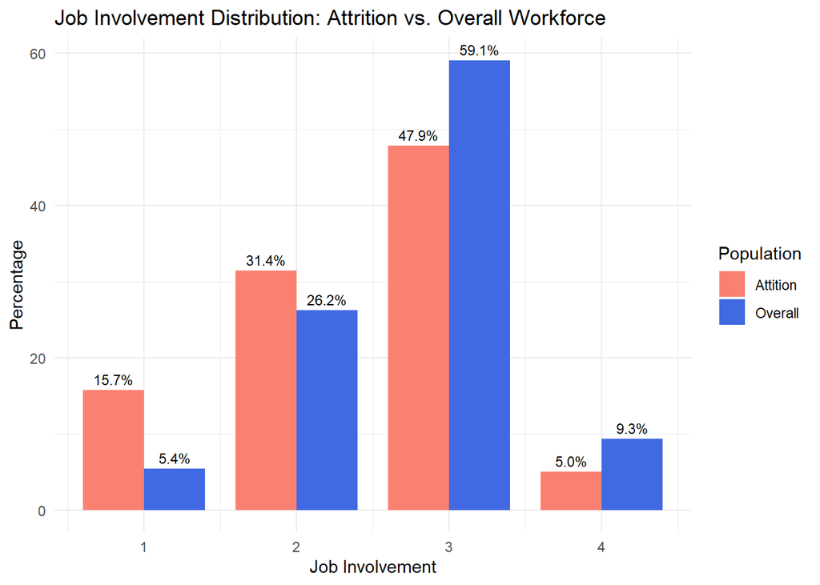

```r
# Comparing Job Involvement distributions between the overall workforce and the attrition group.
Comp = Attr_JI
Comp$Overall = Comp$count/870*100
Comp$Attition = Comp$Yes/140*100
Comp_long <- gather(Comp, Population, Pct, c(Overall,Attition))

# Create the barplot
Comp_long %>% ggplot(aes(x=JobInvolvement, y=Pct, fill=Population, label=Pct)) + geom_col(width=0.8, position='dodge') + geom_text(aes(label= sprintf("%.1f%%", Pct)), position=position_dodge(0.8), vjust=-0.5, size=3)  + labs(x="Job Involvement", y="Percentage", title="Job Involvement Distribution: Attrition vs. Overall Workforce") + theme_minimal() +  scale_fill_manual(values = c("salmon", "royalblue"))
```

The percentage of employees who left the company and rated their job involvement at levels 1 or 2 was higher than the corresponding percentage across the entire company. This suggests that those with lower job involvement experienced a relatively higher attrition rate.

Notably, 47% of departing employees rated their job involvement at levels 1 or 2. This underscores job involvement as one of the top contributing factors to employee attrition.

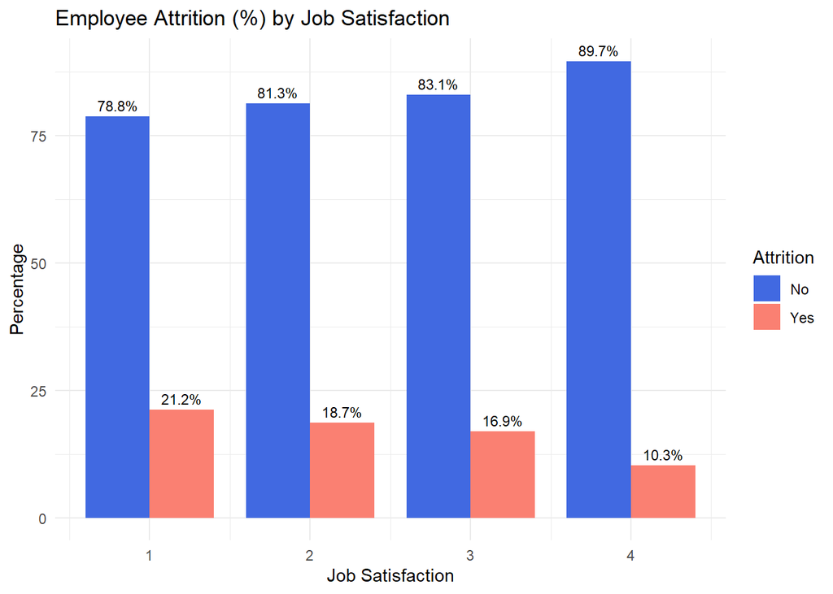

```r
# Attrition by Job Satisfaction
# Total number of employees in each Job Satisfaction
Attr_JB = case %>% select(JobSatisfaction, Attrition) %>% group_by(JobSatisfaction) %>% summarise(count=n())

# Find out the number of each Attrition status for each Job Satisfaction
# Combine the result with Attr_JB data frame
Attr_JB <- cbind(Attr_JB,as.data.frame.matrix(table(case$JobSatisfaction, case$Attrition)))

# Make Attr_JB into long dataset
Attr_JB_long <- gather(Attr_JB, Attrition, Qty, c(Yes,No))
# Add column and calculate the percentage of attrition
Attr_JB_long$pct = Attr_JB_long$Qty / Attr_JB_long$count *100

# Create the barplot
Attr_JB_long %>% ggplot(aes(x=JobSatisfaction, y=pct, fill=Attrition, label=pct)) + geom_col(width=0.8, position='dodge') + geom_text(aes(label= sprintf("%.1f%%", pct)), position=position_dodge(0.8), vjust=-0.5, size=3) + labs(x="Job Satisfaction", y="Percentage", title="Employee Attrition (%) by Job Satisfaction") + theme_minimal() + scale_fill_manual(values = c("royalblue", "salmon"))
```

Compared to Job Involvement, there is less difference between each level in Job Satisfaction. Ranging from level 1 to 4, where level 1 symbolizes the least job satisfaction, the percentages of ‘Yes’ Attrition are 21.2%, 18.7%, 16.9%, and 10.3%, respectively.

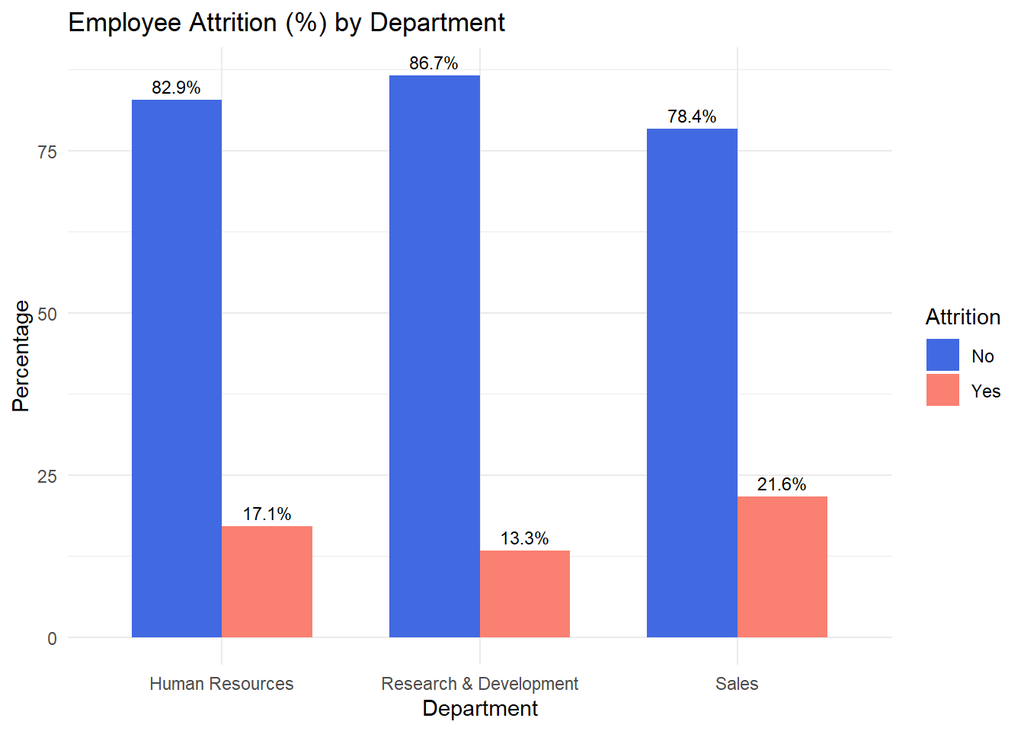

```r
# Attrition by Department
# Total number of employees based on Department
Attr_D = case %>% select(Department, Attrition) %>% group_by(Department) %>% summarise(count=n())

# Find out the number of each Attrition status for each Department
# Combine the result with Attr_D data frame
Attr_D <- cbind(Attr_D,as.data.frame.matrix(table(case$Department, case$Attrition)))

# Make Attr_D into long dataset
Attr_D_long <- gather(Attr_D, Attrition, Qty, c(Yes,No))
# Add column and calculate the percentage of attrition
Attr_D_long$pct = Attr_D_long$Qty / Attr_D_long$count *100

# Create the barplot
Attr_D_long %>% ggplot(aes(x=Department, y=pct, fill=Attrition, label=pct)) + geom_col(width=0.7, position='dodge') + geom_text(aes(label= sprintf("%.1f%%", pct)), position=position_dodge(0.7), vjust=-0.5, size=3) + labs(x="Department", y="Percentage", title="Employee Attrition (%) by Department") + theme_minimal() + scale_fill_manual(values = c("royalblue", "salmon"))
```

The bar plot indicates that the attrition rate in the Sales department (21.6%) is higher than that in the Human Resources (17.1%), which, in turn, is higher than that in Research & Development (13.3%).

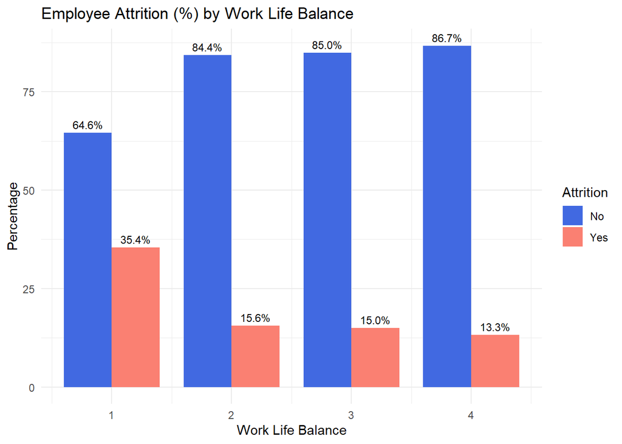

```r
# Attrition by Work Life Balance
# Total number of employees based on Work Life Balance
Attr_WLB = case %>% select(WorkLifeBalance, Attrition) %>% group_by(WorkLifeBalance) %>% summarise(count=n())

# Find out the number of each Attrition status for each Work Life Balance
# Combine the result with Attr_WLB data frame
Attr_WLB <- cbind(Attr_WLB,as.data.frame.matrix(table(case$WorkLifeBalance, case$Attrition)))

# Make Attr_WLB into long dataset
Attr_WLB_long <- gather(Attr_WLB, Attrition, Qty, c(Yes,No))
# Add column and calculate the percentage of attrition
Attr_WLB_long$pct = Attr_WLB_long$Qty / Attr_WLB_long$count *100

# Create the barplot
Attr_WLB_long %>% ggplot(aes(x=WorkLifeBalance, y=pct, fill=Attrition, label=pct)) + geom_col(width=0.8, position='dodge') + geom_text(aes(label= sprintf("%.1f%%", pct)), position=position_dodge(0.8), vjust=-0.5, size=3) + labs(x="Work Life Balance", y="Percentage", title="Employee Attrition (%) by Work Life Balance") + theme_minimal() + scale_fill_manual(values = c("royalblue", "salmon"))
```

For the variable WorkLifeBalance, where level 1 represents the least work-life balance and level 4 represents the most, the percentage of employees who rated their work-life balance at level 1 and left the company (35.4%) significantly differs from those at levels 2 (15.6%), 3 (15.0%), and 4 (13.3%). This suggests that employees with the least work/life balance were more likely to leave the company than their counterparts.

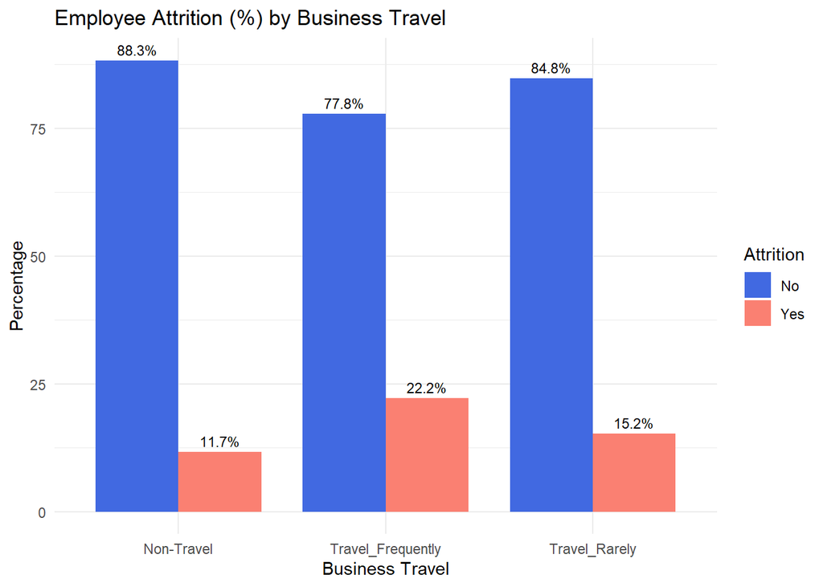

```r
# Attrition by Business Travel
# Total number of employees based on BusinessTravel
Attr_BT = case %>% select(BusinessTravel, Attrition) %>% group_by(BusinessTravel) %>% summarise(count=n())

# Find out the number of each Attrition status for each BusinessTravel
# Combine the result with Attr_BT data frame
Attr_BT <- cbind(Attr_BT,as.data.frame.matrix(table(case$BusinessTravel, case$Attrition)))

# Make Attr_BT into long dataset
Attr_BT_long <- gather(Attr_BT, Attrition, Qty, c(Yes,No))
# Add column and calculate the percentage of attrition
Attr_BT_long$pct = Attr_BT_long$Qty / Attr_BT_long$count *100

# Create the barplot
Attr_BT_long %>% ggplot(aes(x=BusinessTravel, y=pct, fill=Attrition, label=pct)) + geom_col(width=0.8, position='dodge') + geom_text(aes(label= sprintf("%.1f%%", pct)), position=position_dodge(0.8), vjust=-0.5, size=3) + labs(x="Business Travel", y="Percentage", title="Employee Attrition (%) by Business Travel") + theme_minimal() + scale_fill_manual(values = c("royalblue", "salmon"))
```

The percentage of employees who traveled frequently and left the company (22.2%) was higher than for those who traveled rarely (15.2%), which, in turn, was higher than for those who did not travel for business (11.7%).

Considering the potential impact of frequent work-related travel on work/life balance, this supports the trend that employees with the least work/life balance were more likely to leave the company than their counterparts.

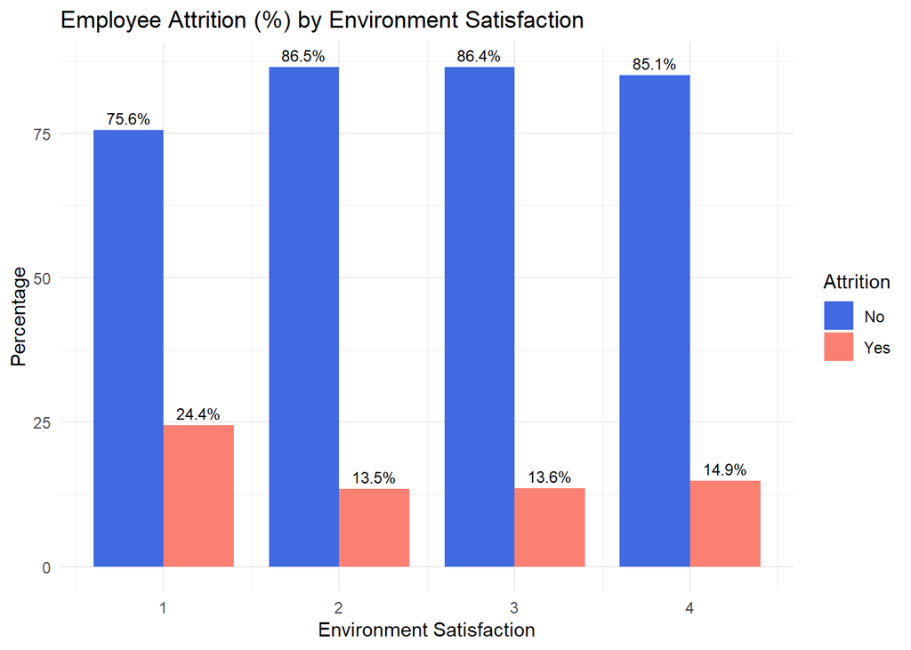

```r
# Attrition by EnvironmentSatisfaction
# Total number of employees based on EnvironmentSatisfaction
Attr_ES = case %>% select(EnvironmentSatisfaction, Attrition) %>% group_by(EnvironmentSatisfaction) %>% summarise(count=n())

# Find out the number of each Attrition status for each EnvironmentSatisfaction
# Combine the result with Attr_ES data frame
Attr_ES <- cbind(Attr_ES,as.data.frame.matrix(table(case$EnvironmentSatisfaction, case$Attrition)))

# Make Attr_ES into long dataset
Attr_ES_long <- gather(Attr_ES, Attrition, Qty, c(Yes,No))
# Add column and calculate the percentage of attrition
Attr_ES_long$pct = Attr_ES_long$Qty / Attr_ES_long$count *100

# Create the barplot
Attr_ES_long %>% ggplot(aes(x=EnvironmentSatisfaction, y=pct, fill=Attrition, label=pct)) + geom_col(width=0.8, position='dodge') + geom_text(aes(label= sprintf("%.1f%%", pct)), position=position_dodge(0.8), vjust=-0.5, size=3) + labs(x="Environment Satisfaction", y="Percentage", title="Employee Attrition (%) by Environment Satisfaction") + theme_minimal() + scale_fill_manual(values = c("royalblue", "salmon"))
```

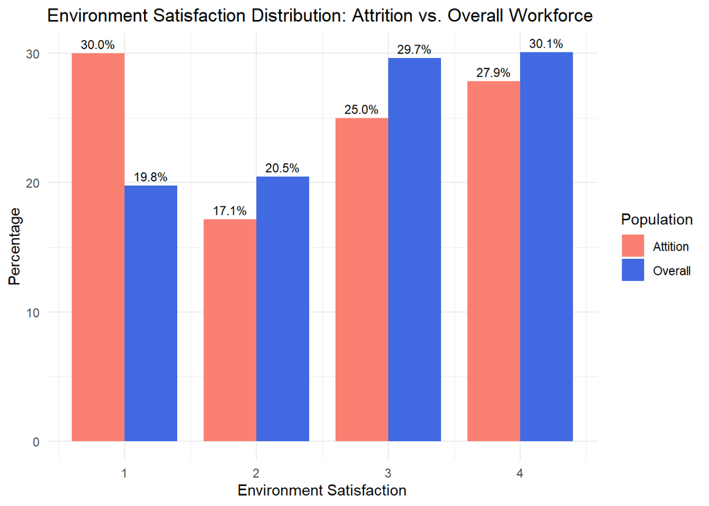

```r
# Comparing Environment Satisfaction distributions between the overall workforce and the attrition group.
Comp = Attr_ES
Comp$Overall = Comp$count/870*100
Comp$Attition = Comp$Yes/140*100
Comp_long <- gather(Comp, Population, Pct, c(Overall,Attition))

# Create the barplot
Comp_long %>% ggplot(aes(x=EnvironmentSatisfaction, y=Pct, fill=Population, label=Pct)) + geom_col(width=0.8, position='dodge') + geom_text(aes(label= sprintf("%.1f%%", Pct)), position=position_dodge(0.8), vjust=-0.5, size=3)  + labs(x="Environment Satisfaction", y="Percentage", title="Environment Satisfaction Distribution: Attrition vs. Overall Workforce") + theme_minimal() +  scale_fill_manual(values = c("salmon", "royalblue"))
```

For the variable EnvironmentSatisfaction, where level 1 symbolizes the least satisfaction and level 4 symbolizes the most:

The first bar plot indicates a notable difference in the percentage of employees who rated environment satisfaction at level 1 and left the company (24.4%), compared to levels 2 (13.5%), 3 (13.6%), and 4 (14.9%). The second bar plot further shows that the percentage of employees leaving the company and rating environment satisfaction at level 1 is higher than the corresponding percentage of level 1 across the entire company. This suggests that those expressing the least satisfaction with their work environment had a relatively higher attrition rate.

Notably, 30% of those who left the company rated their environment satisfaction at level 1, emphasizing that employees with the least satisfaction were more likely to leave than their counterparts.

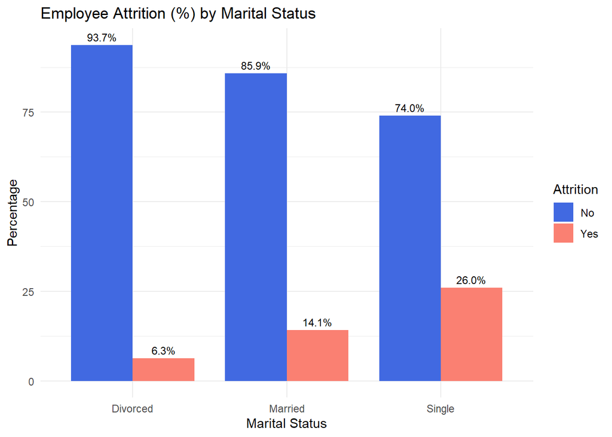

```r
# Attrition by Marital Status
# Total number of employees based on Marital Status
Attr_MS = case %>% select(MaritalStatus, Attrition) %>% group_by(MaritalStatus) %>% summarise(count=n())

# Find out the number of each Attrition status for each Marital Status
# Combine the result with Attr_MS data frame
Attr_MS <- cbind(Attr_MS,as.data.frame.matrix(table(case$MaritalStatus, case$Attrition)))

# Make Attr_MS into long dataset
Attr_MS_long <- gather(Attr_MS, Attrition, Qty, c(Yes,No))
# Add column and calculate the percentage of attrition
Attr_MS_long$pct = Attr_MS_long$Qty / Attr_MS_long$count *100

# Create the barplot
Attr_MS_long %>% ggplot(aes(x=MaritalStatus, y=pct, fill=Attrition, label=pct)) + geom_col(width=0.8, position='dodge') + geom_text(aes(label= sprintf("%.1f%%", pct)), position=position_dodge(0.8), vjust=-0.5, size=3) + labs(x="Marital Status", y="Percentage", title="Employee Attrition (%) by Marital Status") + theme_minimal() + scale_fill_manual(values = c("royalblue", "salmon"))
```

The percentage of employees who were single and left the company (26%) significantly differs from those who were married (14.1%) and those who were divorced (6.3%).

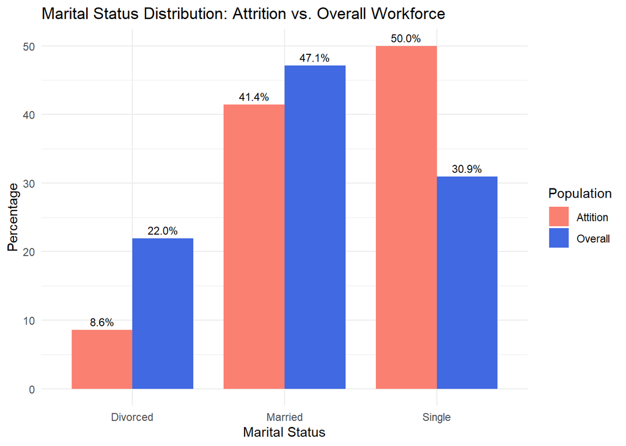

```r
# Comparing Marital Status distributions between the overall workforce and the attrition group.
Comp = Attr_MS
Comp$Overall = Comp$count/870*100
Comp$Attition = Comp$Yes/140*100
Comp_long <- gather(Comp, Population, Pct, c(Overall,Attition))

# Create the barplot
Comp_long %>% ggplot(aes(x=MaritalStatus, y=Pct, fill=Population, label=Pct)) + geom_col(width=0.8, position='dodge') + geom_text(aes(label= sprintf("%.1f%%", Pct)), position=position_dodge(0.8), vjust=-0.5, size=3)  + labs(x="Marital Status", y="Percentage", title="Marital Status Distribution: Attrition vs. Overall Workforce") + theme_minimal() +  scale_fill_manual(values = c("salmon", "royalblue"))
```

The percentage of employees who left the company and were single was significantly higher than the corresponding percentage of singles across the entire company. This suggests that, in terms of composition, single individuals experienced a relatively higher attrition rate.

Notably, 50% of those who left the company were single, underscoring marital status as one of the top indicative factors in employee attrition.

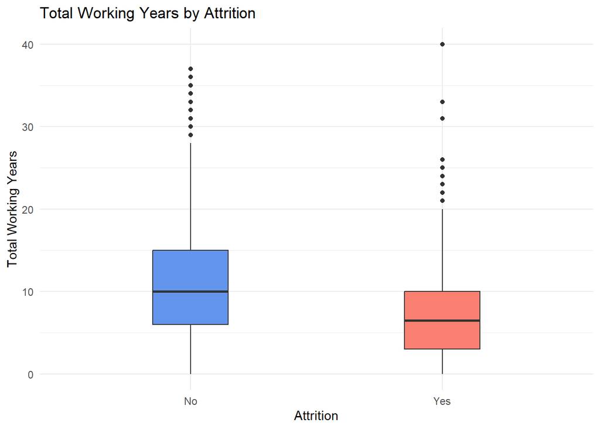

```r
# Boxplot - TotalWorkingYears by attrition
case %>% ggplot(aes(x = Attrition, y = TotalWorkingYears, fill = Attrition)) + geom_boxplot(width = 0.3, show.legend = FALSE) + labs(x="Attrition", y="Total Working Years", title="Total Working Years by Attrition") + theme_minimal() + scale_fill_manual(values = c("cornflowerblue", "salmon"))
```

```r
# Run a t-test on attrition status means
A_yes = as.data.frame(case$TotalWorkingYears[case$Attrition == "Yes"])
A_No = as.data.frame(case$TotalWorkingYears[case$Attrition == "No"])

t.test(x = A_yes, y = A_No, conf.int = .95, alternative = "two.sided")
```

```
##
##  Welch Two Sample t-test
##
## data:  A_yes and A_No
## t = -5.1364, df = 201.19, p-value = 6.596e-07
## alternative hypothesis: true difference in means is not equal to 0
## 95 percent confidence interval:
##  -4.728792 -2.105259
## sample estimates:
## mean of x mean of y
##  8.185714 11.602740
```

```r
# Find medians
case %>%  group_by(Attrition) %>% summarize(MedianTotalWorkingYears = median(TotalWorkingYears))
```

```
## # A tibble: 2 × 2
##   Attrition MedianTotalWorkingYears
##   <chr>                       <dbl>
## 1 No                           10
## 2 Yes                           6.5
```

There is evidence to suggest that the mean total working years of employees who left the company is different from the mean total working years of those who stayed (p-value < 0.0001 < 0.05 from Welch’s t-test).  
Median “Yes” ~ 6.5 years  
Median “No” ~ 10 years

Employees in the early stages of their careers were more likely to leave.

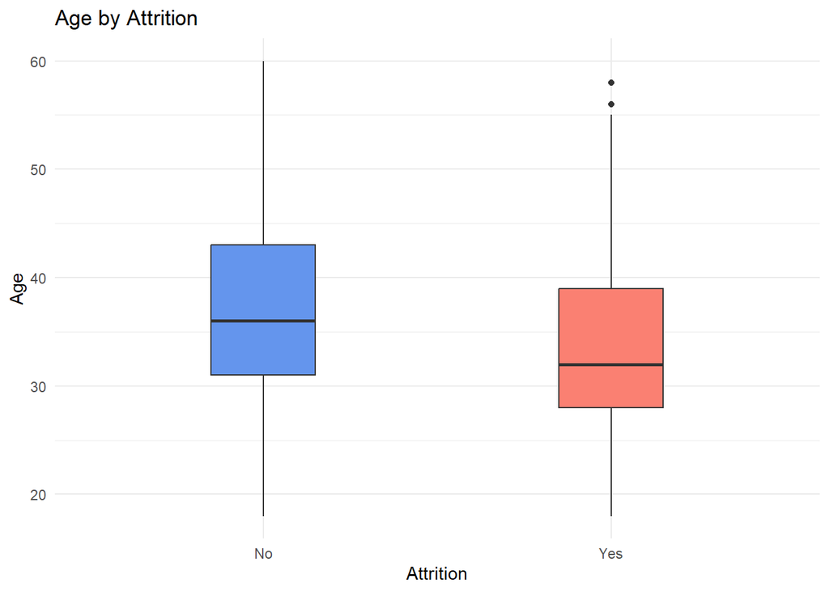

```r
# Boxplot - Age by attrition
case %>% ggplot(aes(x = Attrition, y = Age, fill = Attrition)) + geom_boxplot(width = 0.3, show.legend = FALSE) + labs(x="Attrition", y="Age", title="Age by Attrition") + theme_minimal() + scale_fill_manual(values = c("cornflowerblue", "salmon"))
```

```r
# Run a t-test on attrition status means
A_yes = as.data.frame(case$Age[case$Attrition == "Yes"])
A_No = as.data.frame(case$Age[case$Attrition == "No"])

t.test(x = A_yes, y = A_No, conf.int = .95, alternative = "two.sided")
```

```
##
##  Welch Two Sample t-test
##
## data:  A_yes and A_No
## t = -4.1509, df = 184.91, p-value = 5.05e-05
## alternative hypothesis: true difference in means is not equal to 0
## 95 percent confidence interval:
##  -5.350324 -1.902905
## sample estimates:
## mean of x mean of y
##  33.78571  37.41233
```

```r
# Find medians
case %>%  group_by(Attrition) %>% summarize(MedianAge = median(Age))
```

```
## # A tibble: 2 × 2
##   Attrition MedianAge
##   <chr>         <dbl>
## 1 No               36
## 2 Yes              32
```

There is sufficient evidence to suggest that the mean age of employees who left the company is different from the mean age of those who stayed (p-value < 0.0001 < 0.05 from Welch’s t-test).  
Median of “Yes”: 32 years  
Median of “No”: 36 years

Building on the previously mentioned factor, younger employees in the earlier stages of their careers were more likely to leave.

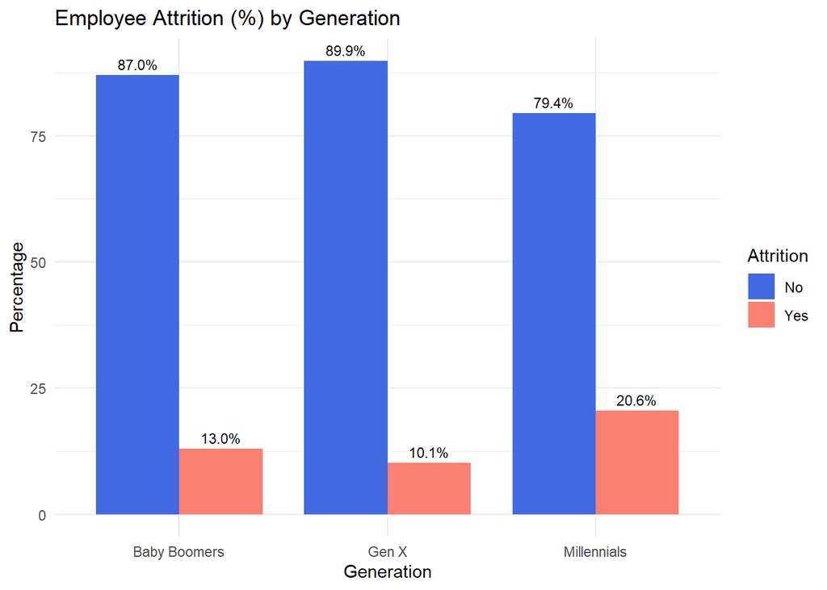

```r
# Age vs. Attrition -- Generation vs. Attrition
case$Generation <- ifelse(case$Age<37,"Millennials",
ifelse(case$Age>=37 & case$Age<53,"Gen X","Baby Boomers"))
case$Generation = as.factor(case$Generation)

# Total number of employees in each generation
Attr_Gen = case %>% select(Generation, Attrition) %>% group_by(Generation) %>% summarise(count=n())

# Find out percentage of Attrition for each generation
Attr_Gen <- cbind(Attr_Gen,as.data.frame.matrix(table(case$Generation, case$Attrition)))

# Make Attr_Gen into long dataset
Attr_Gen_long <- gather(Attr_Gen, Attrition, Qty, c(Yes,No))
# Add column and calculate the percentage of attrition
Attr_Gen_long$pct = Attr_Gen_long$Qty / Attr_Gen_long$count *100

# Create the barplot
Attr_Gen_long %>% ggplot(aes(x=Generation, y=pct, fill=Attrition, label=pct)) + geom_col(width=0.8, position='dodge') + geom_text(aes(label= sprintf("%.1f%%", pct)), position=position_dodge(0.8), vjust=-0.5, size=3) + labs(x="Generation", y="Percentage", title="Employee Attrition (%) by Generation") + theme_minimal() + scale_fill_manual(values = c("royalblue", "salmon"))
```

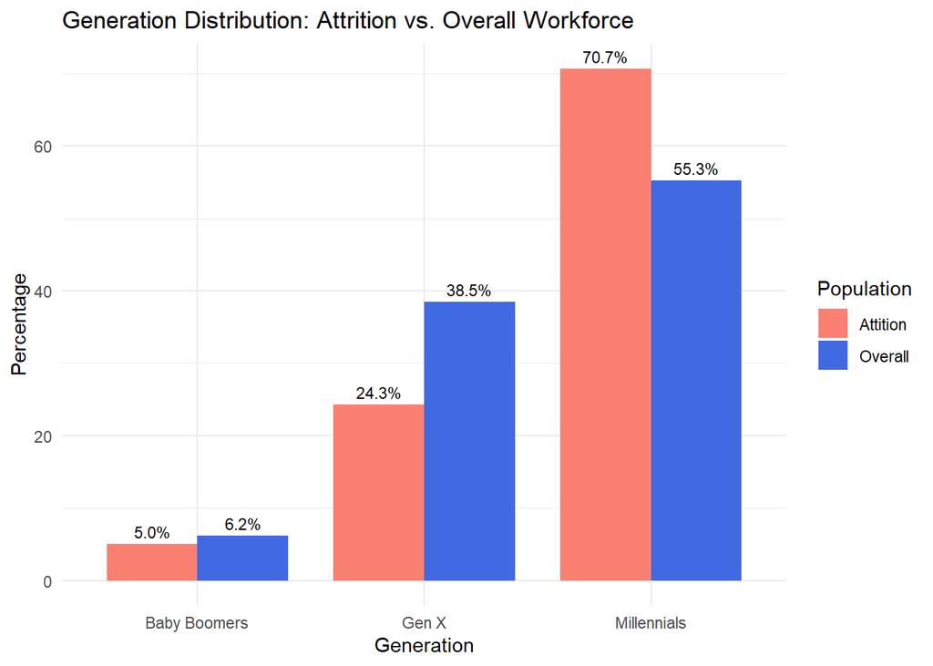

```r
# Comparing Generation distributions between the overall workforce and the attrition group.
Comp = Attr_Gen
Comp$Overall = Comp$count/870*100
Comp$Attition = Comp$Yes/140*100
Comp_long <- gather(Comp, Population, Pct, c(Overall,Attition))

# Create the barplot
Comp_long %>% ggplot(aes(x=Generation, y=Pct, fill=Population, label=Pct)) + geom_col(width=0.8, position='dodge') + geom_text(aes(label= sprintf("%.1f%%", Pct)), position=position_dodge(0.8), vjust=-0.5, size=3)  + labs(x="Generation", y="Percentage", title="Generation Distribution: Attrition vs. Overall Workforce") + theme_minimal() +  scale_fill_manual(values = c("salmon", "royalblue"))
```

Notably, 70% of those who left the company were Millennials, emphasizing age/generation as one of the top influencing factors in employee attrition.

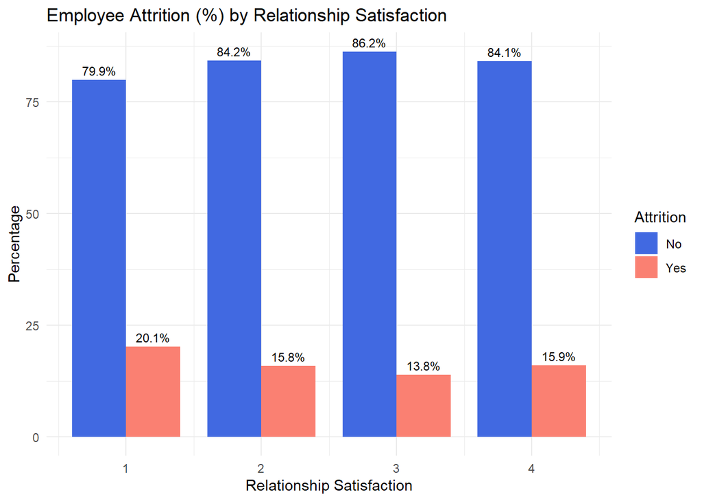

```r
# Attrition by Relationship Satisfaction
# Total number of employees in each Relationship Satisfaction
Attr_RS = case %>% select(RelationshipSatisfaction, Attrition) %>% group_by(RelationshipSatisfaction) %>% summarise(count=n())

# Find out the number of each Attrition status for each Relationship Satisfaction
# Combine the result with Attr_RS data frame
Attr_RS <- cbind(Attr_RS,as.data.frame.matrix(table(case$RelationshipSatisfaction, case$Attrition)))

# Make Attr_RS into long dataset
Attr_RS_long <- gather(Attr_RS, Attrition, Qty, c(Yes,No))
# Add column and calculate the percentage of attrition
Attr_RS_long$pct = Attr_RS_long$Qty / Attr_RS_long$count *100

# Create the barplot
Attr_RS_long %>% ggplot(aes(x=RelationshipSatisfaction, y=pct, fill=Attrition, label=pct)) + geom_col(width=0.8, position='dodge') + geom_text(aes(label= sprintf("%.1f%%", pct)), position=position_dodge(0.8), vjust=-0.5, size=3) + labs(x="Relationship Satisfaction", y="Percentage", title="Employee Attrition (%) by Relationship Satisfaction") + theme_minimal() + scale_fill_manual(values = c("royalblue", "salmon"))
```

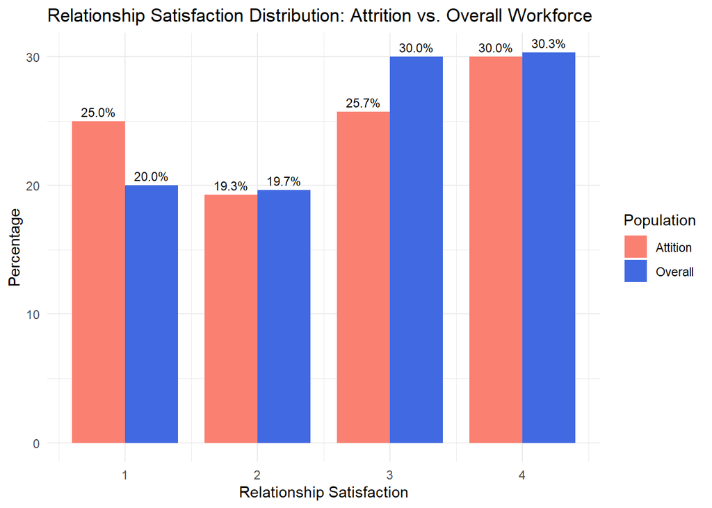

```r
# Comparing Relationship Satisfaction distributions between the overall workforce and the attrition group.
Comp = Attr_RS
Comp$Overall = Comp$count/870*100
Comp$Attition = Comp$Yes/140*100
Comp_long <- gather(Comp, Population, Pct, c(Overall,Attition))

# Create the barplot
Comp_long %>% ggplot(aes(x=RelationshipSatisfaction, y=Pct, fill=Population, label=Pct)) + geom_col(width=0.8, position='dodge') + geom_text(aes(label= sprintf("%.1f%%", Pct)), position=position_dodge(0.8), vjust=-0.5, size=3)  + labs(x="Relationship Satisfaction", y="Percentage", title="Relationship Satisfaction Distribution: Attrition vs. Overall Workforce") + theme_minimal() +  scale_fill_manual(values = c("salmon", "royalblue"))
```

For the variable RelationshipSatisfaction, where level 1 symbolizes the least satisfaction with the manager and level 4 symbolizes the most:

The first bar plot indicates that the percentage of employees who left the company after rating their relationship satisfaction at level 1 (20.1%) is higher than those in levels 2 (15.8%), 3 (13.8%), and 4 (15.9%).

According to the second bar plot, the percentage of employees (25%) who left the company and rated their relationship satisfaction at level 1 was also higher than the corresponding percentage for those across the entire company. This implies that, in terms of composition, those who rated their relationship satisfaction the least experienced a relatively higher attrition rate.

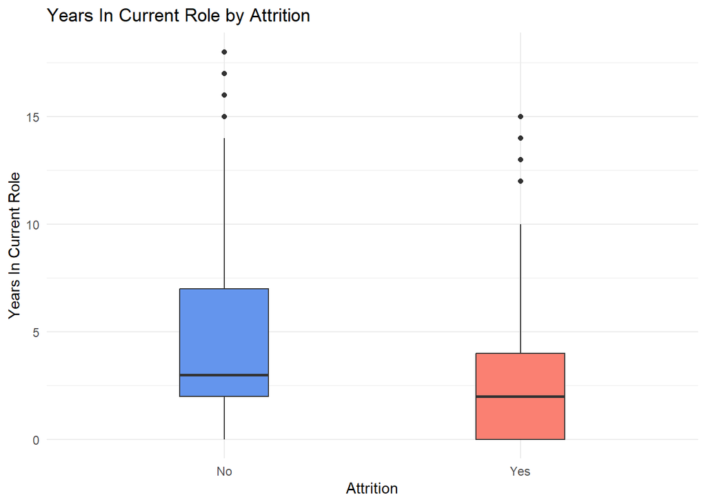

```r
# Boxplot - YearsInCurrentRole by attrition
case %>% ggplot(aes(x = Attrition, y = YearsInCurrentRole, fill = Attrition)) + geom_boxplot(width = 0.3, show.legend = FALSE) + labs(x="Attrition", y="Years In Current Role", title="Years In Current Role by Attrition") + theme_minimal() + scale_fill_manual(values = c("cornflowerblue", "salmon"))
```

```r
# Run a t-test on attrition status means
A_yes = as.data.frame(case$YearsInCurrentRole[case$Attrition == "Yes"])
A_No = as.data.frame(case$YearsInCurrentRole[case$Attrition == "No"])

t.test(x = A_yes, y = A_No, conf.int = .95, alternative = "two.sided")
```

```
##
##  Welch Two Sample t-test
##
## data:  A_yes and A_No
## t = -4.9513, df = 208, p-value = 1.522e-06
## alternative hypothesis: true difference in means is not equal to 0
## 95 percent confidence interval:
##  -2.1619584 -0.9306052
## sample estimates:
## mean of x mean of y
##  2.907143  4.453425
```

```r
# Find Medians
case %>%  group_by(Attrition) %>% summarize(MedianYearsInCurrentRole = median(YearsInCurrentRole))
```

```
## # A tibble: 2 × 2
##   Attrition MedianYearsInCurrentRole
##   <chr>                        <dbl>
## 1 No                               3
## 2 Yes                              2
```

There is evidence to suggest that the mean years in current role in the “Yes” Attrition group is different from the mean years in current role in the “No” Attrition group (p-value < 0.0001 < 0.05 from Welch’s t-test).  
Median “Yes” ~ 2 years  
Median “No” ~ 3 years  
However, it’s worth noting that the difference in medians was not practically significant.

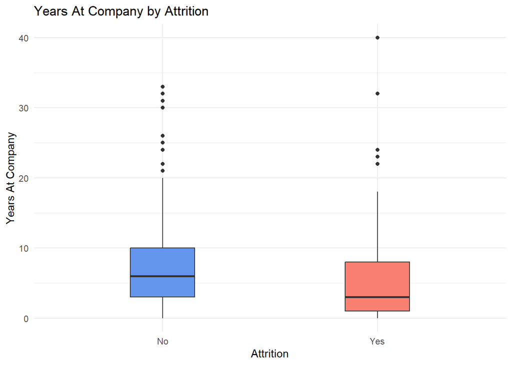

```r
# Boxplot - YearsAtCompany by attrition
case %>% ggplot(aes(x = Attrition, y = YearsAtCompany, fill = Attrition)) + geom_boxplot(width = 0.3, show.legend = FALSE) + labs(x="Attrition", y="Years At Company", title="Years At Company by Attrition") + theme_minimal() + scale_fill_manual(values = c("cornflowerblue", "salmon"))
```

```r
# Run a t-test on attrition status means
A_yes = as.data.frame(case$YearsAtCompany[case$Attrition == "Yes"])
A_No = as.data.frame(case$YearsAtCompany[case$Attrition == "No"])

t.test(x = A_yes, y = A_No, conf.int = .95, alternative = "two.sided")
```

```
##
##  Welch Two Sample t-test
##
## data:  A_yes and A_No
## t = -3.7256, df = 191.55, p-value = 0.0002563
## alternative hypothesis: true difference in means is not equal to 0
## 95 percent confidence interval:
##  -3.2248155 -0.9922099
## sample estimates:
## mean of x mean of y
##  5.192857  7.301370
```

```r
# Find Medians
case %>%  group_by(Attrition) %>% summarize(MedianYearsAtCompany = median(YearsAtCompany))
```

```
## # A tibble: 2 × 2
##   Attrition MedianYearsAtCompany
##   <chr>                    <dbl>
## 1 No                           6
## 2 Yes                          3
```

There is strong evidence to suggest that the mean years at company of the “Yes” Attrition group is different from the mean years at company of the “No” Attrition group (p-value = 0.0002563 < 0.05 from Welch’s t-test).

Median of “Yes” = 3  
Median of “No” = 6

The median years at the company for employees who left were shorter than for those who stayed. Employees who stayed were more likely to have been with the company for a longer duration compared to those who left.

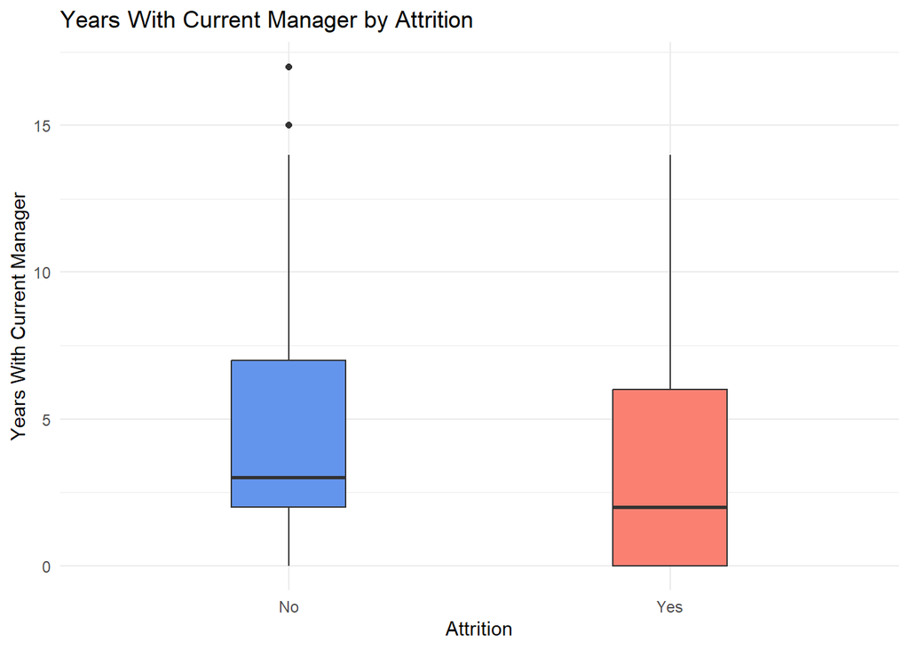

```r
# Boxplot - YearsWithCurrManager by attrition
case %>% ggplot(aes(x = Attrition, y = YearsWithCurrManager, fill = Attrition)) + geom_boxplot(width = 0.3, show.legend = FALSE) + labs(x="Attrition", y="Years With Current Manager", title="Years With Current Manager by Attrition") + theme_minimal() + scale_fill_manual(values = c("cornflowerblue", "salmon"))
```

```r
# Run a t-test on attrition status means
A_yes = as.data.frame(case$YearsWithCurrManager[case$Attrition == "Yes"])
A_No = as.data.frame(case$YearsWithCurrManager[case$Attrition == "No"])

t.test(x = A_yes, y = A_No, conf.int = .95, alternative = "two.sided")
```

```
##
##  Welch Two Sample t-test
##
## data:  A_yes and A_No
## t = -4.6826, df = 209.75, p-value = 5.084e-06
## alternative hypothesis: true difference in means is not equal to 0
## 95 percent confidence interval:
##  -2.0277679 -0.8262439
## sample estimates:
## mean of x mean of y
##  2.942857  4.369863
```

```r
# Find Medians
case %>%  group_by(Attrition) %>% summarize(MedianYearsWithCurrManager = median(YearsWithCurrManager))
```

```
## # A tibble: 2 × 2
##   Attrition MedianYearsWithCurrManager
##   <chr>                          <dbl>
## 1 No                                 3
## 2 Yes                                2
```

There is evidence to suggest that the mean years with current manager of the “Yes” Attrition group is different from the mean years with current manager of the “No” Attrition group (p-value < 0.0001 < 0.05 from Welch’s t-test).  
Median of “Yes” = 2 years  
Median of “No” = 3 years  
However, it’s worth noting that the difference in medians was not practically significant.

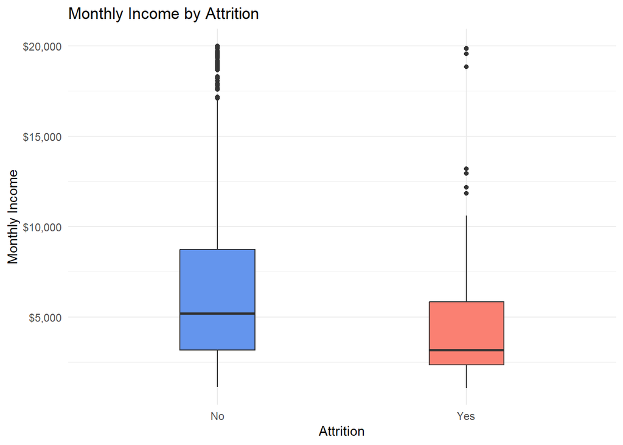

```r
# Boxplot - MonthlyIncome by attrition
case %>% ggplot(aes(x = Attrition, y = MonthlyIncome, fill = Attrition)) + geom_boxplot(width = 0.3, show.legend = FALSE) + labs(x="Attrition", y="Monthly Income", title="Monthly Income by Attrition") + theme_minimal() + scale_y_continuous(labels = scales::dollar_format()) + scale_fill_manual(values = c("cornflowerblue", "salmon"))
```

```r
# Run a t-test on attrition status means
Income_yes = as.data.frame(case$MonthlyIncome[case$Attrition == "Yes"])
Income_No = as.data.frame(case$MonthlyIncome[case$Attrition == "No"])

t.test(x = Income_yes, y = Income_No, conf.int = .95, alternative = "two.sided")
```

```
##
##  Welch Two Sample t-test
##
## data:  Income_yes and Income_No
## t = -5.3249, df = 228.45, p-value = 2.412e-07
## alternative hypothesis: true difference in means is not equal to 0
## 95 percent confidence interval:
##  -2654.047 -1220.382
## sample estimates:
## mean of x mean of y
##  4764.786  6702.000
```

```r
# Find Medians
case %>%  group_by(Attrition) %>% summarize(MedianMonthlyIncome = median(MonthlyIncome))
```

```
## # A tibble: 2 × 2
##   Attrition MedianMonthlyIncome
##   <chr>                   <dbl>
## 1 No                      5208.
## 2 Yes                     3171
```

There is strong evidence to suggest that the mean monthly income of the “Yes” Attrition group is different from the mean monthly income of the “No” Attrition group (p-value < 0.0001 < 0.05 from Welch’s t-test).  
The mean and median monthly income of the employees who left were lower than the mean and median monthly income of those who stayed.

Mean of “Yes” = $4765  
Mean of “No” = $6702  
Median of “Yes” = $3171  
Median of “No” = $5208

One of the top reasons employees left their current company is due to low compensation.

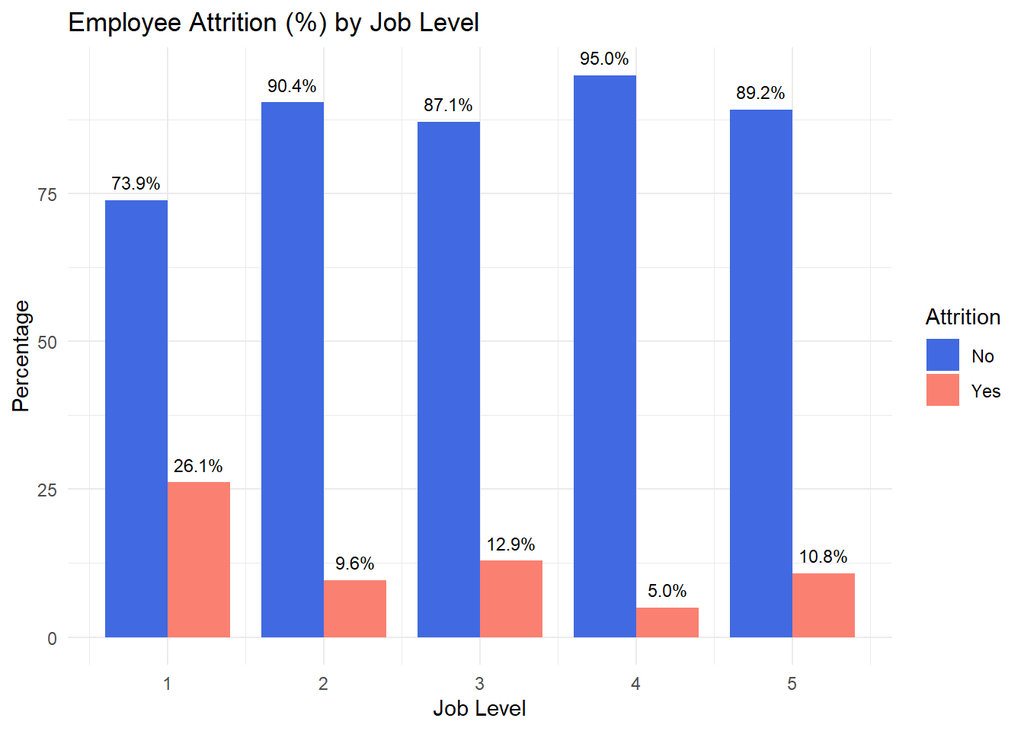

```r
# Attrition by JobLevel
# Total number of employees based on JobLevel
Attr_JL = case %>% select(JobLevel, Attrition) %>% group_by(JobLevel) %>% summarise(count=n())

# Find out the number of each Attrition status for each JobLevel
# Combine the result with Attr_JL data frame
Attr_JL <- cbind(Attr_JL,as.data.frame.matrix(table(case$JobLevel, case$Attrition)))

# Make Attr_JL into long dataset
Attr_JL_long <- gather(Attr_JL, Attrition, Qty, c(Yes,No))
# Add column and calculate the percentage of attrition
Attr_JL_long$pct = Attr_JL_long$Qty / Attr_JL_long$count *100

# Create the barplot
Attr_JL_long %>% ggplot(aes(x=JobLevel, y=pct, fill=Attrition, label=pct)) + geom_col(width=0.8, position='dodge') + geom_text(aes(label= sprintf("%.1f%%", pct)), position=position_dodge(0.8), vjust=-0.8, size=3)  + labs(x="Job Level", y="Percentage", title="Employee Attrition (%) by Job Level") + theme_minimal() + scale_fill_manual(values = c("royalblue", "salmon"))
```

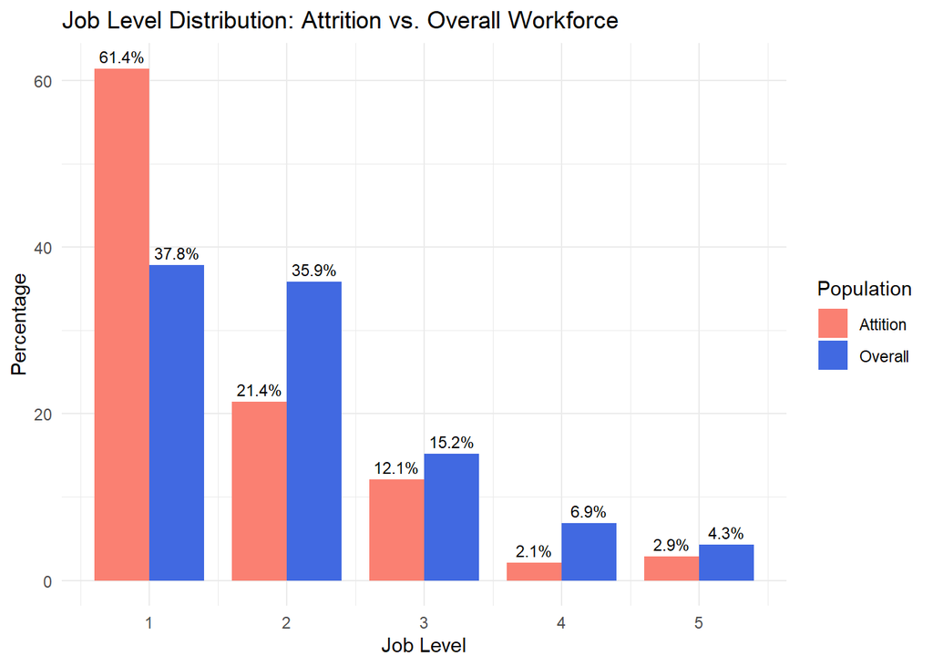

```r
# Comparing Job Level distributions between the overall workforce and the attrition group.
Comp = Attr_JL
Comp$Overall = Comp$count/870*100
Comp$Attition = Comp$Yes/140*100
Comp_long <- gather(Comp, Population, Pct, c(Overall,Attition))

# Create the barplot
Comp_long %>% ggplot(aes(x=JobLevel, y=Pct, fill=Population, label=Pct)) + geom_col(width=0.8, position='dodge') + geom_text(aes(label= sprintf("%.1f%%", Pct)), position=position_dodge(0.8), vjust=-0.5, size=3)  + labs(x="Job Level", y="Percentage", title="Job Level Distribution: Attrition vs. Overall Workforce") + theme_minimal() +  scale_fill_manual(values = c("salmon", "royalblue"))
```

The first bar plot indicates that 26% of employees at job level 1 left the company, notably higher than other levels, suggesting that those at the lowest job level were more likely to leave. This aligns with the strong correlation between monthly income and job level, supporting the observation that those who left had a lower median monthly income.

The second bar plot reinforces this, showing that the percentage of employees who left and were at job level 1 was significantly higher than the corresponding percentage for job level 1 across the entire company. This implies that individuals in job level 1 had a relatively higher attrition rate.

Notably, 61.4% of employees who left were at job level 1, emphasizing job level as one of the top contributing factors to employee attrition.

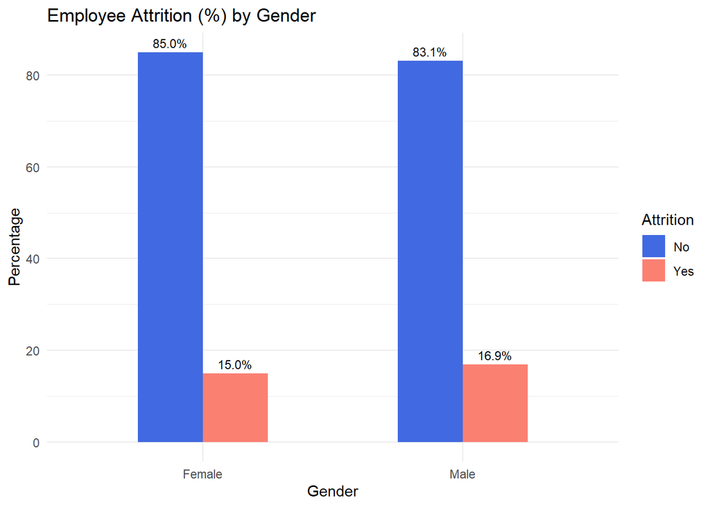

```r
# Attrition by Gender
# Total number of employees based on Gender
Attr_G = case %>% select(Gender, Attrition) %>% group_by(Gender) %>% summarise(count=n())

# Find out the number of each Attrition status for each Gender
# Combine the result with Attr_G data frame
Attr_G <- cbind(Attr_G,as.data.frame.matrix(table(case$Gender, case$Attrition)))

# Make Attr_G into long dataset
Attr_G_long <- gather(Attr_G, Attrition, Qty, c(Yes,No))
# Add column and calculate the percentage of attrition
Attr_G_long$pct = Attr_G_long$Qty / Attr_G_long$count *100

# Create the barplot
Attr_G_long %>% ggplot(aes(x=Gender, y=pct, fill=Attrition, label=pct)) + geom_col(width=0.5, position='dodge') + geom_text(aes(label= sprintf("%.1f%%", pct)), position=position_dodge(0.5), vjust=-0.5, size=3) + labs(x="Gender", y="Percentage", title="Employee Attrition (%) by Gender") + theme_minimal() +scale_fill_manual(values = c("royalblue", "salmon"))
```

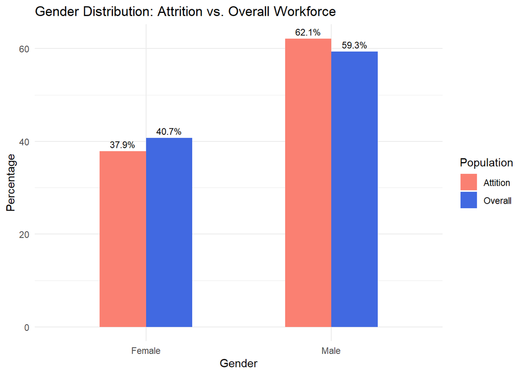

```r
# Comparing Gender distributions between the overall workforce and the attrition group.
Comp = Attr_G
Comp$Overall = Comp$count/870*100
Comp$Attition = Comp$Yes/140*100
Comp_long <- gather(Comp, Population, Pct, c(Overall,Attition))

# Create the barplot
Comp_long %>% ggplot(aes(x=Gender, y=Pct, fill=Population, label=Pct)) + geom_col(width=0.5, position='dodge') + geom_text(aes(label= sprintf("%.1f%%", Pct)), position=position_dodge(0.5), vjust=-0.5, size=3)  + labs(x="Gender", y="Percentage", title="Gender Distribution: Attrition vs. Overall Workforce") + theme_minimal() +  scale_fill_manual(values = c("salmon", "royalblue"))
```

The first bar plot indicates a slightly higher attrition rate among male employees (16.9%) compared to females (15.0%).

The second bar plot shows that the percentage of employees who left and were male (62%) is slightly higher than the corresponding percentage of male employees across the entire company (59%). This supports the observation of a slightly higher attrition rate among male employees.

### Job Role specific trends

```r
# See JobRole only, from pairwise correlation conducted earlier.
Jcor_p = cor_p %>% filter(var2 == "JobRole")
# Arrange by the absolute value of correlation coefficients in descending order
Jcor_p = arrange(Jcor_p, desc(abs(cor)))
# The top 10 variables of the list
Jcor_p[2:11,]
```

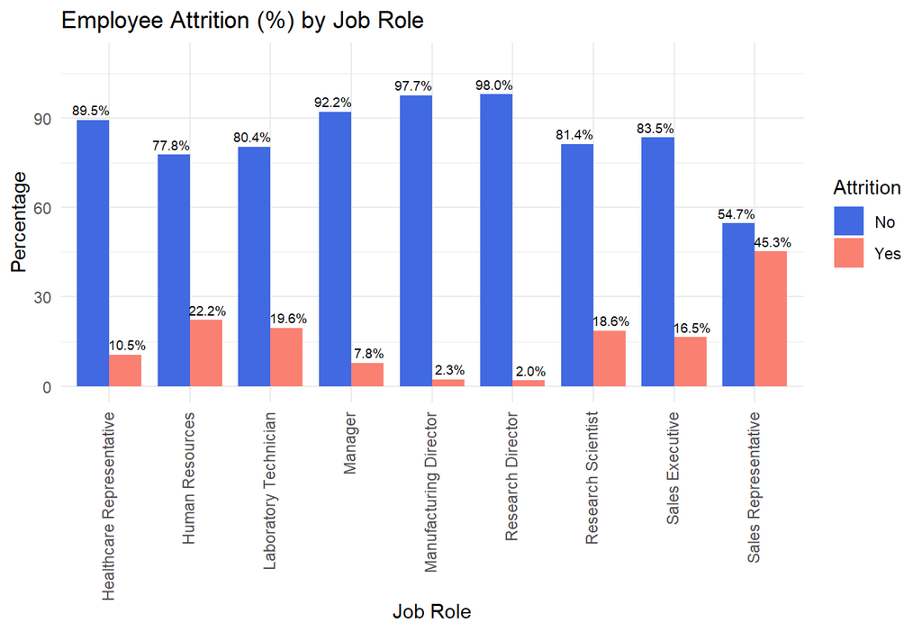

```r
# Attrition by JobRole
# Total number of employees based on JobRole
Attr_JR = case %>% select(JobRole, Attrition) %>% group_by(JobRole) %>% summarise(count=n())

# Find out the number of each Attrition status for each JobRole
# Combine the result with Attr_JR data frame
Attr_JR <- cbind(Attr_JR,as.data.frame.matrix(table(case$JobRole, case$Attrition)))

# Make Attr_JR into long dataset
Attr_JR_long <- gather(Attr_JR, Attrition, Qty, c(Yes,No))
# Add column and calculate the percentage of attrition
Attr_JR_long$pct = Attr_JR_long$Qty / Attr_JR_long$count *100

# Create the barplot
Attr_JR_long %>% ggplot(aes(x=JobRole, y=pct, fill=Attrition, label=pct)) + geom_col(width=0.8, position='dodge') + geom_text(aes(label= sprintf("%.1f%%", pct)), position=position_dodge(0.9), vjust=-0.5, size=2.5) + ylim(0,110) + labs(x="Job Role", y="Percentage", title="Employee Attrition (%) by Job Role") + theme_minimal() + theme(axis.text.x = element_text(angle = 90, vjust = 0.3, hjust=1)) +  scale_fill_manual(values = c("royalblue", "salmon"))
```

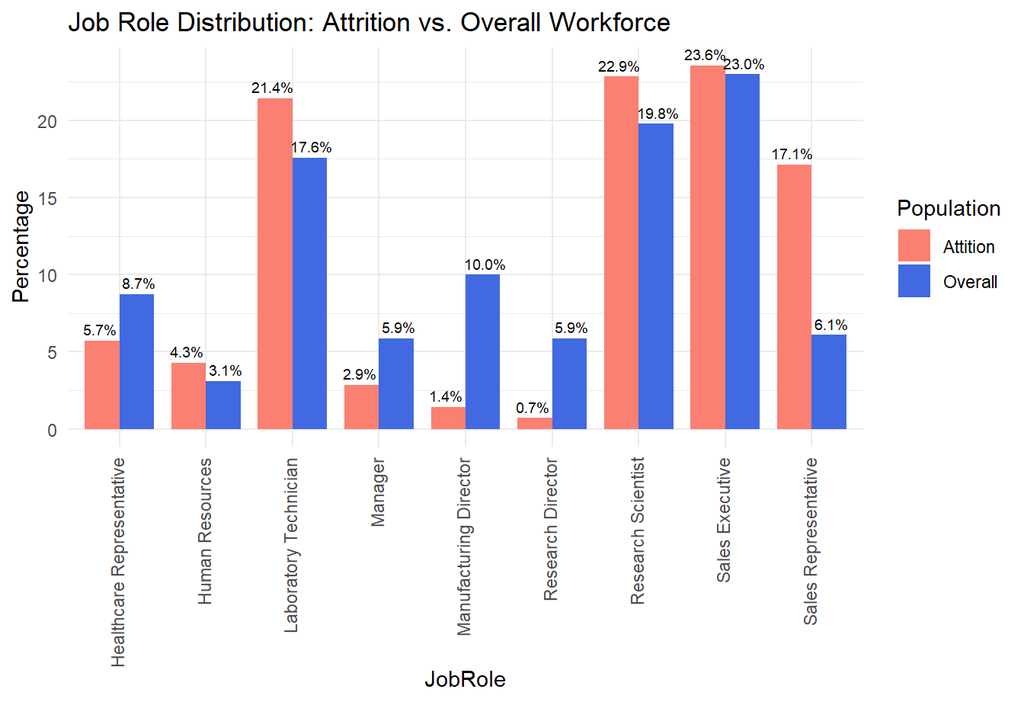

```r
# Comparing Job Role distributions between the overall workforce and the attrition group
Comp = Attr_JR
Comp$Overall = Comp$count/870*100
Comp$Attition = Comp$Yes/140*100
Comp_long <- gather(Comp, Population, Pct, c(Overall,Attition))

# Create the barplot
Comp_long %>% ggplot(aes(x=JobRole, y=Pct, fill=Population, label=Pct)) + geom_col(width=0.8, position='dodge') + geom_text(aes(label= sprintf("%.1f%%", Pct)), position=position_dodge(0.9), vjust=-0.5, size=2.5)  + labs(x="JobRole", y="Percentage", title="Job Role Distribution: Attrition vs. Overall Workforce") + theme_minimal() +  scale_fill_manual(values = c("salmon", "royalblue")) + theme(axis.text.x = element_text(angle = 90, vjust = 0.3, hjust=1))
```

The first bar plot reveals that the percentage of Sales Representatives who left the company (45.3%) was the highest and significantly higher than the percentages of other job roles. Notably, the percentages of Research Directors (2.0%), Manufacturing Directors (2.3%), and Managers (7.8%) who left the company were the lowest among the job roles.

According to the second bar plot, the percentage of employees who left the company and were Sales Representatives (17%) was notably higher than the corresponding percentage for those across the entire company (6%), exhibiting the most difference (11%) in terms of composition compared to other job roles.

Notably, the percentages of employees who left the company and were Human Resources, Laboratory Technician, and Research Scientist were also higher than their corresponding percentages across the entire company.

Job role is one of the top indicative factors in employee attrition.

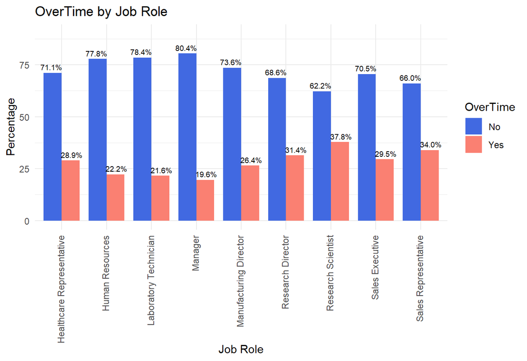

```r
# OverTime by JobRole
# Total number of employees based on JobRole
OT_JR = case %>% select(JobRole, OverTime) %>% group_by(JobRole) %>% summarise(count=n())

# Find out the number of each OverTime status for each JobRole
# Combine the result with OT_JR data frame
OT_JR <- cbind(OT_JR,as.data.frame.matrix(table(case$JobRole, case$OverTime)))

# Make OT_JR into long dataset
OT_JR_long <- gather(OT_JR, OverTime, Qty, c(Yes,No))
# Add column and calculate the percentage of attrition
OT_JR_long$pct = OT_JR_long$Qty / OT_JR_long$count *100

# Create the barplot
OT_JR_long %>% ggplot(aes(x=JobRole, y=pct, fill=OverTime, label=pct)) + geom_col(width=0.8, position='dodge') + geom_text(aes(label= sprintf("%.1f%%", pct)), position=position_dodge(0.9), vjust=-0.5, size=2.5) + ylim(0,90) + labs(x="Job Role", y="Percentage", title="OverTime by Job Role") + theme_minimal() + theme(axis.text.x = element_text(angle = 90, vjust = 0.3, hjust=1)) +  scale_fill_manual(values = c("royalblue", "salmon"))
```

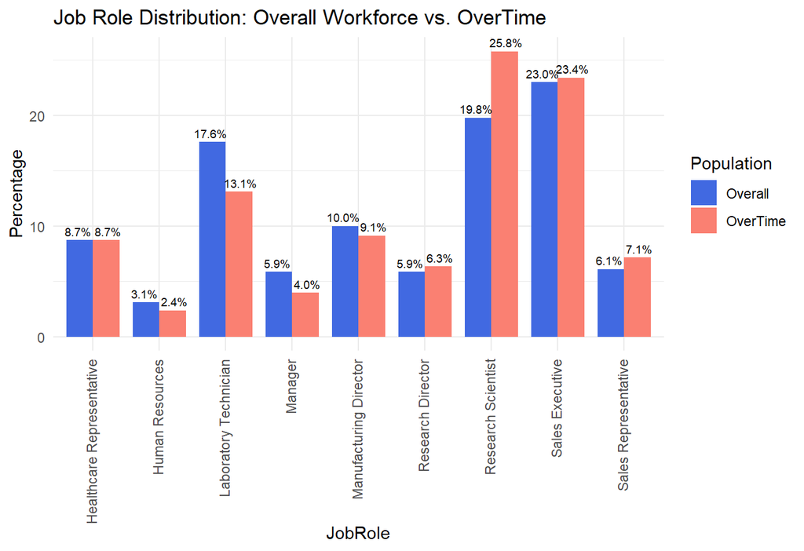

```r
# Comparing Job Role distributions between the overall workforce and OverTime
Comp = OT_JR
Comp$Overall = Comp$count/870*100
Comp$OverTime = Comp$Yes/252*100
Comp_long <- gather(Comp, Population, Pct, c(Overall,OverTime))

# Create the barplot
Comp_long %>% ggplot(aes(x=JobRole, y=Pct, fill=Population, label=Pct)) + geom_col(width=0.8, position='dodge') + geom_text(aes(label= sprintf("%.1f%%", Pct)), position=position_dodge(0.9), vjust=-0.5, size=2.5)  + labs(x="JobRole", y="Percentage", title="Job Role Distribution: Overall Workforce vs. OverTime") + theme_minimal() +  scale_fill_manual(values = c("royalblue", "salmon")) + theme(axis.text.x = element_text(angle = 90, vjust = 0.3, hjust=1))
```

According to the first bar plot, about 38% of Research Scientists worked overtime, exceeding the percentage for Sales Representatives. The lowest was Manager, 19.6% of them worked overtime.

In the second bar plot, approximately 26% of employees who worked overtime were Research Scientists, higher than the corresponding percentage (20%) for those across the entire company. This suggests that Research Scientists were more likely to work overtime.

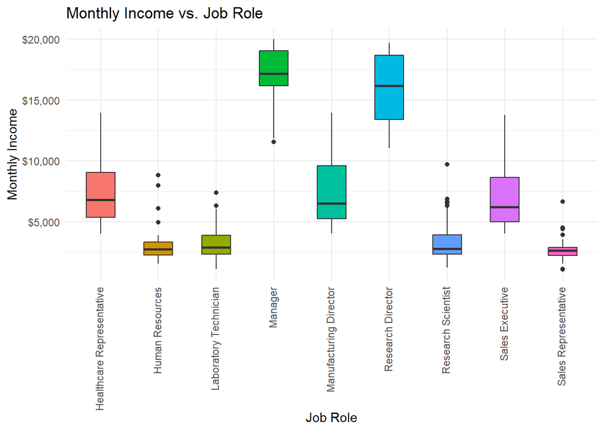

```r
# Boxplot - MonthlyIncome by JobRole
case %>% ggplot(aes(x = JobRole, y = MonthlyIncome, fill = JobRole)) + geom_boxplot(width = 0.5, show.legend = FALSE) + labs(x="Job Role", y="Monthly Income", title="Monthly Income vs. Job Role") + theme_minimal() + theme(axis.text.x = element_text(angle = 90, vjust = 0.3, hjust=1)) + scale_y_continuous(labels = scales::dollar_format())
```

```r
# Group by JobRole and calculate the median MonthlyIncome
case %>%  group_by(JobRole) %>% summarize(MedianMonthlyIncome = median(MonthlyIncome))
```

```
## # A tibble: 9 × 2
##   JobRole                   MedianMonthlyIncome
##   <chr>                                   <dbl>
## 1 Healthcare Representative               6796
## 2 Human Resources                         2742
## 3 Laboratory Technician                   2867
## 4 Manager                                17174
## 5 Manufacturing Director                  6499
## 6 Research Director                      16184
## 7 Research Scientist                      2774.
## 8 Sales Executive                         6222
## 9 Sales Representative                    2610
```

Sales Representatives had the lowest median monthly income and the highest attrition rate among other job roles.

Research Directors and Managers had the top two median monthly incomes, followed by Healthcare Representatives, Manufacturing Directors, and Sales Executives.

Human Resources, Laboratory Technicians, Research Scientists, and Sales Representatives had the lowest median monthly incomes, all below the company-wide median monthly income of $5,000.

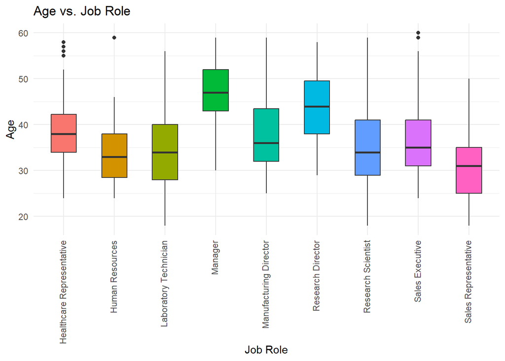

```r
# Boxplot - Age by JobRole
case %>% ggplot(aes(x = JobRole, y = Age, fill = JobRole)) + geom_boxplot(width = 0.5, show.legend = FALSE) + labs(x="Job Role", y="Age", title="Age vs. Job Role") + theme_minimal() + theme(axis.text.x = element_text(angle = 90, vjust = 0.3, hjust=1))
```

```r
# Group by JobRole and calculate the median Age
case %>%  group_by(JobRole) %>% summarize(MedianAge = median(Age))
```

```
## # A tibble: 9 × 2
##   JobRole                   MedianAge
##   <chr>                         <dbl>
## 1 Healthcare Representative        38
## 2 Human Resources                  33
## 3 Laboratory Technician            34
## 4 Manager                          47
## 5 Manufacturing Director           36
## 6 Research Director                44
## 7 Research Scientist               34
## 8 Sales Executive                  35
## 9 Sales Representative             31
```

Among the job roles, Sales Representatives had the lowest median age, while Managers had the highest median age.

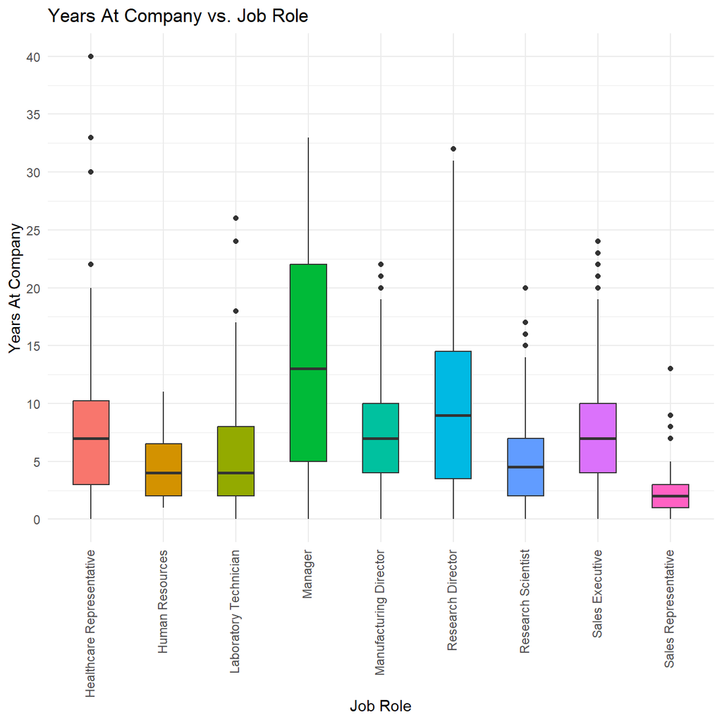

```r
# Boxplot - YearsAtCompany by JobRole
case %>% ggplot(aes(x = JobRole, y = YearsAtCompany, fill = JobRole)) + geom_boxplot(width = 0.5, show.legend = FALSE) + labs(x="Job Role", y="Years At Company", title="Years At Company vs. Job Role") + theme_minimal() + theme(axis.text.x = element_text(angle = 90, vjust = 0.3, hjust=1)) +
  scale_y_continuous(n.breaks=9)
```

```r
# Group by JobRole and calculate the median YearsAtCompany
case %>%  group_by(JobRole) %>% summarize(MedianYearsAtCompany = median(YearsAtCompany))
```

```
## # A tibble: 9 × 2
##   JobRole                   MedianYearsAtCompany
##   <chr>                                    <dbl>
## 1 Healthcare Representative                  7
## 2 Human Resources                            4
## 3 Laboratory Technician                      4
## 4 Manager                                   13
## 5 Manufacturing Director                     7
## 6 Research Director                          9
## 7 Research Scientist                         4.5
## 8 Sales Executive                            7
## 9 Sales Representative                       2
```

Sales Representatives had the lowest median years at the company and the highest attrition rate among other job roles.

Managers tended to stay with the company the longest, having the highest median years at the company among the job roles, followed by Research Directors. In the next tier for median years at the company were Healthcare Representatives, Manufacturing Directors, and Sales Executives. Following them were Human Resources, Laboratory Technicians, and Research Scientists, with their median years at the company higher than that of Sales Representatives.

Considering With the previous findings, Sales Representatives tended to be younger and stayed with the company for a shorter duration, having the lowest median monthly income and a higher attrition rate.

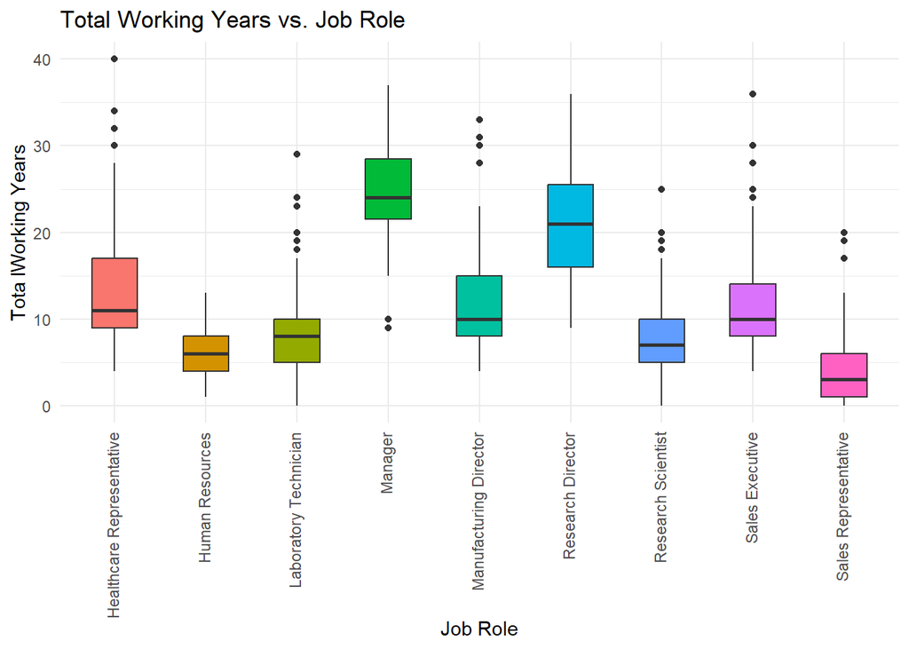

```r
# Boxplot - TotalWorkingYears by JobRole
case %>% ggplot(aes(x = JobRole, y = TotalWorkingYears, fill = JobRole)) + geom_boxplot(width = 0.5, show.legend = FALSE) + labs(x="Job Role", y="Tota lWorking Years", title="Total Working Years vs. Job Role") + theme_minimal() + theme(axis.text.x = element_text(angle = 90, vjust = 0.3, hjust=1))
```

```r
# Group by JobRole and calculate the median TotalWorkingYears
case %>%  group_by(JobRole) %>% summarize(MedianTotalWorkingYears = median(TotalWorkingYears))
```

```
## # A tibble: 9 × 2
##   JobRole                   MedianTotalWorkingYears
##   <chr>                                       <dbl>
## 1 Healthcare Representative                      11
## 2 Human Resources                                 6
## 3 Laboratory Technician                           8
## 4 Manager                                        24
## 5 Manufacturing Director                         10
## 6 Research Director                              21
## 7 Research Scientist                              7
## 8 Sales Executive                                10
## 9 Sales Representative                            3
```

Both Manager and Research Director were the top two median total working years. Sales Representative had the least.

### Summary

1. The top three contributing factors to employee attrition are:
   - Job Level/Monthly Income
   - Overtime
   - Job Involvement
2. The top indicative factors in employee attrition are:
   - Stock Option Level
   - Age/Generation
   - Marital Status
   - Total Working Years

   The indicative factors are separated from the contributing factors because, unlike contributing factors, they cannot be directly modified, such as reducing unnecessary overtime. These factors are mainly the demographics of employee attrition, serving as signs or indicators.
   - Job Roles

Job Role Specific Trends:

1. Sales Representatives:
   - Highest attrition rate
   - Lowest median monthly income
   - Lowest median total working years
   - Lowest median years at company
   - Youngest in term of median age
2. Research Directors and Manufacturing Directors:
   - Lowest attrition rate
3. Managers:
   - Highest median monthly income
   - Highest median total working years
   - Highest median years at company
   - Oldest in term of median age

Research scientists were more likely to work overtime than employees in other job roles.

Manufacturing Directors did not have as high median monthly income, total working years, years at the company, or age as Managers and Research Directors. However, Manufacturing Directors had one of the lowest attrition rates, along with Research Directors. This group is worth further study to identify practices that led to their higher retention rate, in areas such as morale, recognition, environment, support, leadership, etc. The lessons learned may assist in increasing retention rates among Healthcare Representatives and Sales Executives, as they share similar ranges in median monthly income, total working years, years at the company, and age. Furthermore, these insights might contribute to improving the retention of other job roles throughout the company.

## Attrition Model

The two different algorithms used are Naive Bayes and k-Nearest Neighbors. Performance criteria: to attain at least 60% in both sensitivity and specificity.

We conducted numerous iterations of Naive Bayes and k-Nearest Neighbors (k-NN) models, experimenting with various combinations and quantities of variables. They were evaluated based on whether they met the criteria, as well as accuracy.

The final combination of variables chosen includes JobInvolvement, StockOptionLevel, OverTime, MaritalStatus, and JobRole. This combination was chosen because it has relatively higher sensitivity and specificity, with the least number of variables used to avoid overfitting.

Finally, we compare the performance of Naive Bayes and k-NN models using the same chosen variables.

### OverSampling

The oversampling technique is employed to balance the imbalanced dataset.

```r
case3 = case
case3$Attrition = as.factor(case3$Attrition)

# Oversampling for imbalanced dataset
OnlyYes = case3 %>% filter(Attrition == "Yes") # Give me all Yes
# Oversampling of Yes
# seed is set for reproducibility
set.seed(115)
OnlyYesOver = rbind(OnlyYes,OnlyYes[sample(seq(1,140,1),(730-140),replace = TRUE),])
dim(OnlyYesOver)

# Combine the Oversampling of Yes and the rest of the No
OverSamp = rbind(case3 %>% filter(Attrition == "No"), OnlyYesOver)
dim(OverSamp)

# Relevel to Yes as positive class
OverSamp$Attrition = relevel(OverSamp$Attrition, ref = "Yes")

# Split OverSamp into train and validation sets
# seed is set for reproducibility
set.seed(123)
trainIndices = sample(seq(1:dim(OverSamp)[1]),
                      round(.7*dim(OverSamp)[1]))
train = OverSamp[trainIndices,]
test = OverSamp[-trainIndices,]
```

```r
head(train)
head(test)
```

```r
# Make sure the factor levels are in the same order. Relevel to Yes as positive class
#test$Attrition = relevel(test$Attrition, ref = "Yes")
```

### Naive Bayes model

```r
# Naive Bayes

# Model
model = naiveBayes(train[,c('JobInvolvement', 'StockOptionLevel', 'OverTime', 'MaritalStatus', 'JobRole')], train$Attrition)

# Cross Validation
confusionMatrix(table(predict(model,test[,c('JobInvolvement', 'StockOptionLevel', 'OverTime', 'MaritalStatus', 'JobRole')]),
                      test$Attrition), mode = "everything")
```

```
## Confusion Matrix and Statistics
##
##
##       Yes  No
##   Yes 166  60
##   No   64 148
##
##                Accuracy : 0.7169
##                  95% CI : (0.6722, 0.7586)
##     No Information Rate : 0.5251
##     P-Value [Acc > NIR] : <2e-16
##
##                   Kappa : 0.4329
##
##  Mcnemar's Test P-Value : 0.7876
##
##             Sensitivity : 0.7217
##             Specificity : 0.7115
##          Pos Pred Value : 0.7345
##          Neg Pred Value : 0.6981
##               Precision : 0.7345
##                  Recall : 0.7217
##                      F1 : 0.7281
##              Prevalence : 0.5251
##          Detection Rate : 0.3790
##    Detection Prevalence : 0.5160
##       Balanced Accuracy : 0.7166
##
##        'Positive' Class : Yes
##
```

### k-Nearest Neighbors model

```r
# Turn categorical variables to numeric in OverSamp dataset

OverSamp$JobRole[OverSamp$JobRole == "Healthcare Representative"] = 0
OverSamp$JobRole[OverSamp$JobRole == "Human Resources"] = 1
OverSamp$JobRole[OverSamp$JobRole == "Laboratory Technician"] = 2
OverSamp$JobRole[OverSamp$JobRole == "Manager"] = 3
OverSamp$JobRole[OverSamp$JobRole == "Manufacturing Director"] = 4
OverSamp$JobRole[OverSamp$JobRole == "Research Director"] = 5
OverSamp$JobRole[OverSamp$JobRole == "Research Scientist"] = 6
OverSamp$JobRole[OverSamp$JobRole == "Sales Executive"] = 7
OverSamp$JobRole[OverSamp$JobRole == "Sales Representative"] = 8
OverSamp$JobRole = as.numeric(OverSamp$JobRole)

OverSamp$MaritalStatus[OverSamp$MaritalStatus == "Divorced"] = 0
OverSamp$MaritalStatus[OverSamp$MaritalStatus == "Single"] = 1
OverSamp$MaritalStatus[OverSamp$MaritalStatus == "Married"] = 2
OverSamp$MaritalStatus = as.numeric(OverSamp$MaritalStatus)

OverSamp$OverTime[OverSamp$OverTime == "Yes"] = 0
OverSamp$OverTime[OverSamp$OverTime == "No"] = 1
OverSamp$OverTime = as.numeric(OverSamp$OverTime)
```

```r
# k-NN (k=5)

# Split OverSamp into train and validation sets
# seed is set for reproducibility, same as the Naive Bayes
set.seed(123)
trainIndices = sample(seq(1:dim(OverSamp)[1]),
                      round(.7*dim(OverSamp)[1]))
train = OverSamp[trainIndices,]
test = OverSamp[-trainIndices,]
```

```r
head(train)
head(test)
```

```r
# Make sure the factor levels are in the same order. Relevel to Yes as positive class
#test$Attrition = relevel(test$Attrition, ref = "Yes")

# Model
classifications = knn(train[,c('JobInvolvement', 'StockOptionLevel', 'OverTime', 'MaritalStatus', 'JobRole')],test[,c('JobInvolvement', 'StockOptionLevel', 'OverTime', 'MaritalStatus', 'JobRole')], train$Attrition, prob = TRUE, k = 5)

# External Cross Validation
confusionMatrix(table(classifications,test$Attrition), mode = "everything")
```

```
## Confusion Matrix and Statistics
##
##
## classifications Yes  No
##             Yes 186  60
##             No   44 148
##
##                Accuracy : 0.7626
##                  95% CI : (0.7199, 0.8017)
##     No Information Rate : 0.5251
##     P-Value [Acc > NIR] : <2e-16
##
##                   Kappa : 0.5222
##
##  Mcnemar's Test P-Value : 0.1413
##
##             Sensitivity : 0.8087
##             Specificity : 0.7115
##          Pos Pred Value : 0.7561
##          Neg Pred Value : 0.7708
##               Precision : 0.7561
##                  Recall : 0.8087
##                      F1 : 0.7815
##              Prevalence : 0.5251
##          Detection Rate : 0.4247
##    Detection Prevalence : 0.5616
##       Balanced Accuracy : 0.7601
##
##        'Positive' Class : Yes
##
```

```r
# k-NN Leave-One-Out Cross Validation (LOOCV)
classifications = knn.cv(OverSamp[,c('JobInvolvement', 'StockOptionLevel', 'OverTime', 'MaritalStatus', 'JobRole')],OverSamp$Attrition, k=5)

confusionMatrix(table(classifications, OverSamp$Attrition), mode = "everything")
```

```
## Confusion Matrix and Statistics
##
##
## classifications Yes  No
##             Yes 652 252
##             No   78 478
##
##                Accuracy : 0.774
##                  95% CI : (0.7516, 0.7952)
##     No Information Rate : 0.5
##     P-Value [Acc > NIR] : < 2.2e-16
##
##                   Kappa : 0.5479
##
##  Mcnemar's Test P-Value : < 2.2e-16
##
##             Sensitivity : 0.8932
##             Specificity : 0.6548
##          Pos Pred Value : 0.7212
##          Neg Pred Value : 0.8597
##               Precision : 0.7212
##                  Recall : 0.8932
##                      F1 : 0.7980
##              Prevalence : 0.5000
##          Detection Rate : 0.4466
##    Detection Prevalence : 0.6192
##       Balanced Accuracy : 0.7740
##
##        'Positive' Class : Yes
##
```

## Attrition Prediction

```r
# Turn categorical variables to numeric for test_attr before prediction

test_attr$JobRole[test_attr$JobRole == "Healthcare Representative"] = 0
test_attr$JobRole[test_attr$JobRole == "Human Resources"] = 1
test_attr$JobRole[test_attr$JobRole == "Laboratory Technician"] = 2
test_attr$JobRole[test_attr$JobRole == "Manager"] = 3
test_attr$JobRole[test_attr$JobRole == "Manufacturing Director"] = 4
test_attr$JobRole[test_attr$JobRole == "Research Director"] = 5
test_attr$JobRole[test_attr$JobRole == "Research Scientist"] = 6
test_attr$JobRole[test_attr$JobRole == "Sales Executive"] = 7
test_attr$JobRole[test_attr$JobRole == "Sales Representative"] = 8
test_attr$JobRole = as.numeric(test_attr$JobRole)

test_attr$MaritalStatus[test_attr$MaritalStatus == "Divorced"] = 0
test_attr$MaritalStatus[test_attr$MaritalStatus == "Single"] = 1
test_attr$MaritalStatus[test_attr$MaritalStatus == "Married"] = 2
test_attr$MaritalStatus = as.numeric(test_attr$MaritalStatus)

test_attr$OverTime[test_attr$OverTime == "Yes"] = 0
test_attr$OverTime[test_attr$OverTime == "No"] = 1
test_attr$OverTime = as.numeric(test_attr$OverTime)
```

```r
# Prediction for test_attr test set using k-NN model

predictions <- knn(OverSamp[,c('JobInvolvement', 'StockOptionLevel', 'OverTime', 'MaritalStatus', 'JobRole')], test_attr[,c('JobInvolvement', 'StockOptionLevel', 'OverTime', 'MaritalStatus', 'JobRole')], OverSamp$Attrition, k=5)

# Create a new data frame with column ID from test_attr test set
Predict_Attrition = test_attr %>% select("ID")

Predict_Attrition$Attrition = predictions

# Export the results into ,csv file
write.csv(Predict_Attrition, "Case2PredictionsPang Attrition.csv", row.names = FALSE)
```

# Monthly Income

We use a similar approach to that applied to Attrition to identify contributing factors to monthly income and predict monthly income for the test set using a linear regression model.

## Exploratory Data Analysis (EDA)

### Pairwise correlation

Begin by examining correlation coefficients between MonthlyIncome and other variables to gain a general understanding. Subsequently, utilize visualization techniques and additional statistical analyses to further explore these relationships.

```r
# See MonthlyIncome only, from pairwise correlation conducted earlier.
Mcor_p = cor_p %>% filter(var2 == "MonthlyIncome")
# Arrange by absolute value of correlation coefficients in descending order
Mcor_p = arrange(Mcor_p, desc(abs(cor)))
Mcor_p[2:11,]
```

[output not shown]

### Graphs and statistical analysis

JobLevel and TotalWorkingYears had the top two correlation coefficients. We will investigate them further.

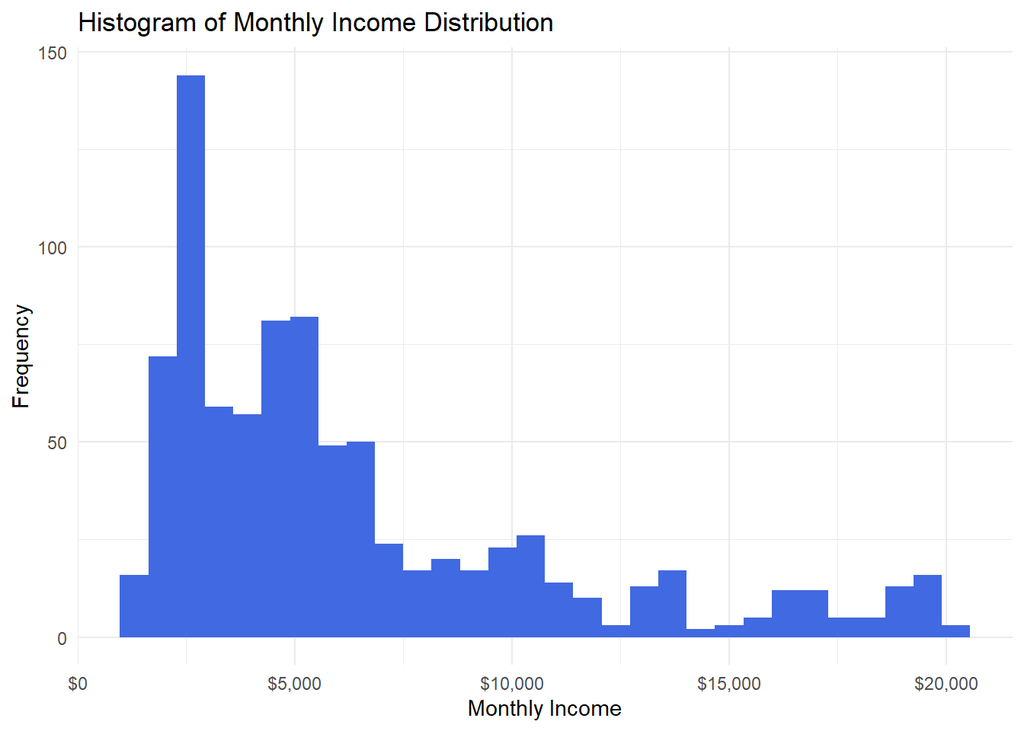

```r
# Monthly Income Distribution
case %>% ggplot(aes(x=MonthlyIncome)) + geom_histogram(fill = "royalblue") + labs(x="Monthly Income", y="Frequency", title="Histogram of Monthly Income Distribution") + theme_minimal() + scale_x_continuous(labels = scales::dollar_format())
```

```r
summary(case$MonthlyIncome)
```

```
##    Min. 1st Qu.  Median    Mean 3rd Qu.    Max.
##    1081    2840    4946    6390    8182   19999
```

The distribution of monthly income is heavily right skewed, with the company’s median monthly income at around $5,000.

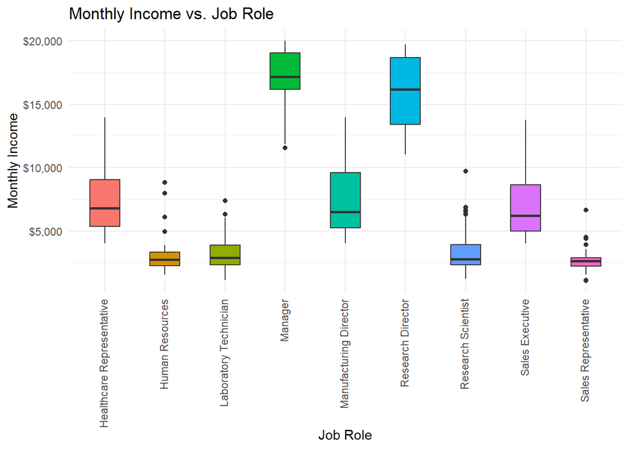

```r
# Boxplot - MonthlyIncome by JobRole
case %>% ggplot(aes(x = JobRole, y = MonthlyIncome, fill = JobRole)) + geom_boxplot(width = 0.5, show.legend = FALSE) + labs(x="Job Role", y="Monthly Income", title="Monthly Income vs. Job Role") + theme_minimal() + theme(axis.text.x = element_text(angle = 90, vjust = 0.3, hjust=1)) + scale_y_continuous(labels = scales::dollar_format())
```

At the highest, both the median monthly income of Managers and Research Directors exceeded $15,000. Next, only Healthcare Representatives, Manufacturing Directors, and Sales Executives had median monthly incomes surpassing the company’s median of $5,000. The median monthly income of all other job roles was below $5,000.

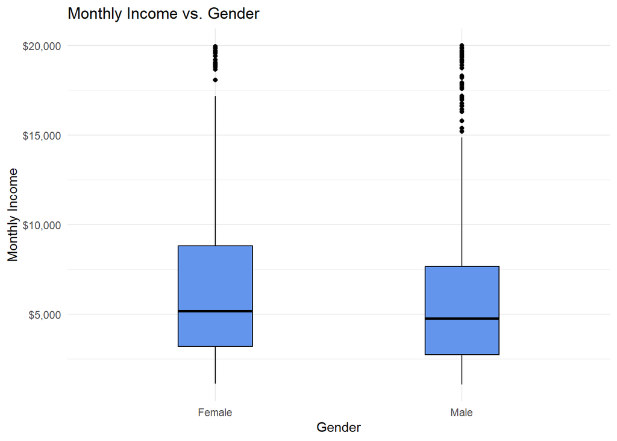

```r
# Boxplot - MonthlyIncome by Gender
case %>% ggplot(aes(x = Gender, y = MonthlyIncome)) + geom_boxplot(fill = "cornflowerblue", color = "black", width = 0.3) + labs(x="Gender", y="Monthly Income", title="Monthly Income vs. Gender") + theme_minimal() + scale_y_continuous(labels = scales::dollar_format())
```

```r
# Run a t-test on mean salary for Gender
Female = as.data.frame(case$MonthlyIncome[case$Gender == "Female"])
Male = as.data.frame(case$MonthlyIncome[case$Gender == "Male"])

t.test(x = Female, y = Male, conf.int = .95, alternative = "two.sided")
```

```
##
##  Welch Two Sample t-test
##
## data:  Female and Male
## t = 1.6207, df = 747.5, p-value = 0.1055
## alternative hypothesis: true difference in means is not equal to 0
## 95 percent confidence interval:
##  -109.0107 1140.8560
## sample estimates:
## mean of x mean of y
##  6696.260  6180.337
```

There is not sufficient evidence to suggest that the mean monthly income of female is different from that of male (p-value = 0.1055 > 0.05 from Welch’s t-test).

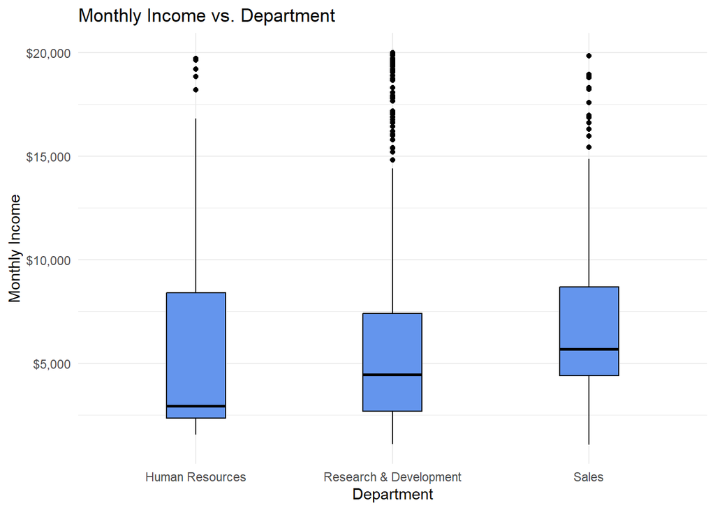

```r
# Boxplot - MonthlyIncome by Department
case %>% ggplot(aes(x = Department, y = MonthlyIncome)) + geom_boxplot(fill = "cornflowerblue", color = "black", width = 0.3) + labs(x="Department", y="Monthly Income", title="Monthly Income vs. Department") + theme_minimal() + scale_y_continuous(labels = scales::dollar_format())
```

Sales had the highest median monthly income among the departments.

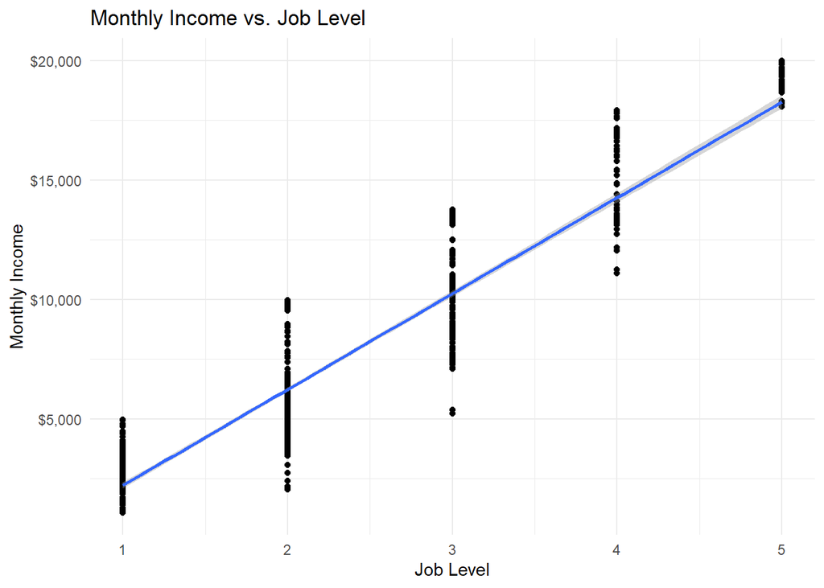

```r
# Scatterplot of Monthly Income vs. Job Level
case %>% ggplot(aes(x=JobLevel, y=MonthlyIncome)) + geom_point() + geom_smooth(method = lm) + labs(x="Job Level", y="Monthly Income", title="Monthly Income vs. Job Level") + theme_minimal() + scale_y_continuous(labels = scales::dollar_format())
```

```r
# To fit a linear regrssion model
fit = lm(MonthlyIncome ~ JobLevel, data = case)
summary(fit)
```

```
##
## Call:
## lm(formula = MonthlyIncome ~ JobLevel, data = case)
##
## Residuals:
##     Min      1Q  Median      3Q     Max
## -5037.1  -928.2    80.1   697.1  3723.6
##
## Coefficients:
##             Estimate Std. Error t value Pr(>|t|)
## (Intercept) -1793.93     101.68  -17.64   <2e-16 ***
## JobLevel     4013.67      43.98   91.26   <2e-16 ***
## ---
## Signif. codes:  0 '***' 0.001 '**' 0.01 '*' 0.05 '.' 0.1 ' ' 1
##
## Residual standard error: 1413 on 868 degrees of freedom
## Multiple R-squared:  0.9056, Adjusted R-squared:  0.9055
## F-statistic:  8329 on 1 and 868 DF,  p-value: < 2.2e-16
```

Monthly Income appears to be correlated with job level, as evident from the scatterplot. The estimated mean monthly income increases with the rise in job level.

The fitted linear regression provides strong evidence suggesting a linear relationship between monthly income and job level (p-value < 0.0001 < 0.05). The Adjusted R-squared value is 0.9055, indicating that 90.55% of the variation in monthly income can be explained by job level.

This finding aligns with common practices, as most companies typically define a salary range for each job level.

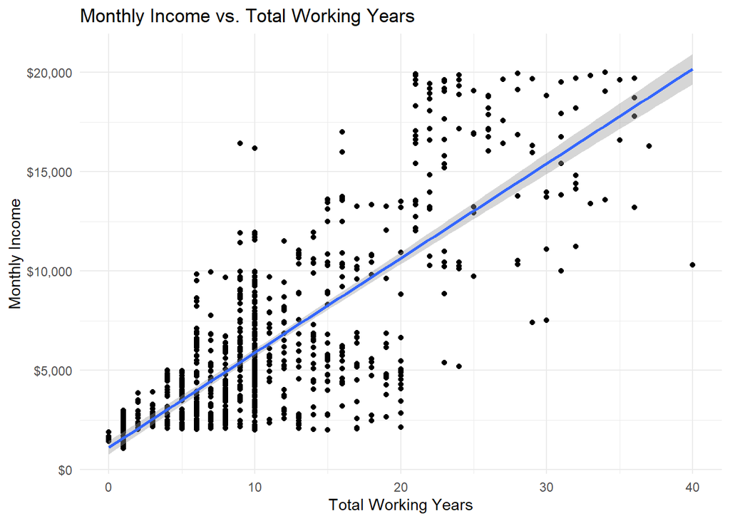

```r
# Scatterplot of Monthly Income vs. Total Working Years
case %>% ggplot(aes(x=TotalWorkingYears, y=MonthlyIncome)) + geom_point() + geom_smooth(method = lm) + labs(x="Total Working Years", y="Monthly Income", title="Monthly Income vs. Total Working Years") + theme_minimal() + scale_y_continuous(labels = scales::dollar_format())
```

```r
fit = lm(MonthlyIncome ~ TotalWorkingYears, data = case)
summary(fit)
```

```
##
## Call:
## lm(formula = MonthlyIncome ~ TotalWorkingYears, data = case)
##
## Residuals:
##     Min      1Q  Median      3Q     Max
## -9868.1 -1703.7   -44.5  1453.1 11009.7
##
## Coefficients:
##                   Estimate Std. Error t value Pr(>|t|)
## (Intercept)        1124.90     174.19   6.458 1.77e-10 ***
## TotalWorkingYears   476.38      13.04  36.544  < 2e-16 ***
## ---
## Signif. codes:  0 '***' 0.001 '**' 0.01 '*' 0.05 '.' 0.1 ' ' 1
##
## Residual standard error: 2887 on 868 degrees of freedom
## Multiple R-squared:  0.6061, Adjusted R-squared:  0.6056
## F-statistic:  1335 on 1 and 868 DF,  p-value: < 2.2e-16
```

Monthly Income appears to be correlated with TotalWorkingYears, as indicated by the scatterplot. The estimated mean monthly income increases as total working years increases.

The fitted linear regression provides strong evidence suggesting a linear relationship between monthly income and the total working years of an employee (p-value < 0.0001 < 0.05). The Adjusted R-squared is 0.6056, meaning that 60.56% of the variation in monthly income can be explained by total working years.

Work experience is typically one of the factors that contribute to determining someone’s salary.

## Monthly Income Model

Using leave-one-out cross validation method, we compare 4 different linear regression models.

Model 1: one explanatory varible: JobLevel  
Model 2: one explanatory varible: TotalWorkingYears  
Model 3: two explanatory varibles: JobLevel and TotalWorkingYears  
Model 4: Model 3 with interaction between JobLevel and TotalWorkingYears

```r
# Change data type to numeric
case$JobLevel <- as.numeric(case$JobLevel)
case$TotalWorkingYears <- as.numeric(as.character(case$TotalWorkingYears))

# Run train functions:
# Model 1:
model <- train(MonthlyIncome ~ JobLevel, method = "lm", data = case, trControl = trainControl(method = "LOOCV"))
model
```

```
## Linear Regression
##
## 870 samples
##   1 predictor
##
## No pre-processing
## Resampling: Leave-One-Out Cross-Validation
## Summary of sample sizes: 869, 869, 869, 869, 869, 869, ...
## Resampling results:
##
##   RMSE      Rsquared   MAE
##   1414.966  0.9051777  1076.208
##
## Tuning parameter 'intercept' was held constant at a value of TRUE
```

```r
# Model 2:
model2 <- train(MonthlyIncome ~ TotalWorkingYears, method = "lm", data = case, trControl = trainControl(method = "LOOCV"))
model2
```

```
## Linear Regression
##
## 870 samples
##   1 predictor
##
## No pre-processing
## Resampling: Leave-One-Out Cross-Validation
## Summary of sample sizes: 869, 869, 869, 869, 869, 869, ...
## Resampling results:
##
##   RMSE      Rsquared   MAE
##   2892.568  0.6037372  2163.593
##
## Tuning parameter 'intercept' was held constant at a value of TRUE
```

```r
# Model 3:
model3 <- train(MonthlyIncome ~ JobLevel + TotalWorkingYears, method = "lm", data = case, trControl = trainControl(method = "LOOCV"))
model3
```

```
## Linear Regression
##
## 870 samples
##   2 predictor
##
## No pre-processing
## Resampling: Leave-One-Out Cross-Validation
## Summary of sample sizes: 869, 869, 869, 869, 869, 869, ...
## Resampling results:
##
##   RMSE      Rsquared   MAE
##   1392.628  0.9081479  1058.106
##
## Tuning parameter 'intercept' was held constant at a value of TRUE
```

```r
# Model 4:
model4 <- train(MonthlyIncome ~ JobLevel * TotalWorkingYears, method = "lm", data = case, trControl = trainControl(method = "LOOCV"))
model4
```

```
## Linear Regression
##
## 870 samples
##   2 predictor
##
## No pre-processing
## Resampling: Leave-One-Out Cross-Validation
## Summary of sample sizes: 869, 869, 869, 869, 869, 869, ...
## Resampling results:
##
##   RMSE      Rsquared  MAE
##   1327.751  0.916507  981.5653
##
## Tuning parameter 'intercept' was held constant at a value of TRUE
```

Model 4 is chosen as it has the least RMSE and MAE, and the highest R-squared.

## Monthly Income Prediction

```r
# Predict for test_salary test set
mi_predict <- predict(model4, newdata = test_salary)

# Create a new data frame with column ID from test_salary test set
Predict_MonthlyIncome = data.frame("ID" = test_salary$ï..ID)
# Input the prediction result into the new data frame
Predict_MonthlyIncome$MonthlyIncome = mi_predict

# Export the results into ,csv file
write.csv(Predict_MonthlyIncome, "Case2PredictionsPang Salary.csv", row.names = FALSE)
```

# Conclusion

Employees are a pivotal component of an organization. In addition to significant cost savings, organizations with low attrition rates tend to excel in innovation, achieve higher productivity levels, and enhance customer satisfaction, making them more appealing to top talent.

The analysis of the employee dataset from Frito Lay provided valuable insights into the key factors influencing attrition within the company. The comprehensive exploration involved statistical methods and visualizations. Here are the key findings:

### Attrition Analysis:

1. The top three contributing factors to employee attrition are:
   - Job Level/Monthly Income
   - Overtime
   - Job Involvement
2. The top indicative factors in employee attrition are:
   - Stock Option Level
   - Age/Generation
   - Marital Status
   - Total Working Years
   - Job Roles

#### Job Role Specific Trends:

1. Sales Representatives:
   - Highest attrition rate
   - Lowest median monthly income
   - Lowest median total working years
   - Lowest median years at company
   - Youngest in term of median age
2. Research Directors and Manufacturing Directors:
   - Lowest attrition rate
3. Managers:
   - Highest median monthly income
   - Highest median total working years
   - Highest median years at company
   - Oldest in term of median age

Manufacturing Directors had one of the lowest attrition rates, making this group worth further study to identify practices that contributed to their relatively higher retention rate. The lessons learned might contribute to improving the retention of other job roles throughout the company.

### Attrition Prediction:

The k-Nearest Neighbors model is chosen for predicting attrition, given its superior performance. The result of the attrition prediction was exported to a .csv file.

### Monthly Income Analysis:

1. High correlation with:
   - Job Level
   - Total Working Years
   - Job Role

### Monthly Income Models:

1. Variables Used:
   - Job Level, Total Working Years
2. Model Comparison:
   - 4 linear regression models
   - The model with the interaction term (Model 4) exhibited the highest R-Squared and the lowest RMSE = $1328 < $3000

### Monthly Income Prediction:

The result of the monthly income prediction was exported to a .csv file.

In conclusion, this comprehensive analysis not only sheds light on the challenges of attrition and income prediction but also equips organizations with the knowledge to foster a resilient, engaged, and high-performing workforce. It underscores the importance of continuous monitoring, strategic planning, and data-driven decision-making in the dynamic landscape of talent management.